# Statistical Machine Learning Final Project

Moran Guo

2024-10-20

Here I report the findings of analyzing `NHANES 2003-2004` to predict the mortality status (binary outcome) for participants 50 years and older.

### Data Cleaning

```r
library(tidyverse)
library(dplyr)

load("~/JHSPH_Stat_ML/nhanes2003-2004.Rda")

data <- nhanes2003_2004
cat("The raw data dimension is:\n")
```

```
## The raw data dimension is:
```

```r
dim(data)
```

```
## [1] 10122   813
```

```r
required_variables <- c("SEQN", "mortstat")  # Include participants' ID, mortality status besides the predictors

predictors <- c("RIDAGEYR", "RIAGENDR", "BPQ010", "BPQ060", "SMQ040", "DIQ010", "DIQ050", "DIQ090", "MCQ010", "MCQ053", "MCQ160A", "MCQ160B", "MCQ160K", "MCQ160L", "BMXWAIST", "MCQ160M", "MCQ220", "MCQ245A", "MCQ250A", "MCQ250B", "MCQ250C", "MCQ250E", "MCQ250F", "MCQ250G", "MCQ265", "SSQ011", "SSQ051", "WHQ030", "WHQ040", "LBXRDW", "HSD010", "BPXPULS", "BPXML1", "VIQ200", "BMXBMI", "BPXSY1", "BPXDI1")
predictors <- unique(c(required_variables, predictors))

missing_predictors <- setdiff(predictors, colnames(data))

cat("The missing predictor is:\n")
```

```
## The missing predictor is:
```

```r
print(missing_predictors)
```

```
## [1] "SMQ040"
```

```r
predictors <- setdiff(predictors, missing_predictors)

data <- subset(data, select = predictors)
#dim(data)

data <- data %>% filter(!is.na(mortstat))

data$RIDAGEYR <- as.numeric(as.character(data$RIDAGEYR))
data <- subset(data, RIDAGEYR >= 50)

cat("The final raw data dimension after removing NA's in `mortstat` and selecting for participants greater than 50 years old is:\n")
```

```
## The final raw data dimension after removing NA's in `mortstat` and selecting for participants greater than 50 years old is:
```

```r
dim(data)
```

```
## [1] 2504   38
```

```r
# Check percentage of NA values

percent_na <- sapply(data, function(col) sum(is.na(col)) / length(col) * 100)
cat("Percentage of NA values before filtering for mortality statuses:\n")
```

```
## Percentage of NA values before filtering for mortality statuses:
```

```r
print(percent_na)
```

```
##      SEQN  mortstat  RIDAGEYR  RIAGENDR    BPQ010    BPQ060    DIQ010    DIQ050
##  0.000000  0.000000  0.000000  0.000000  0.000000  0.000000  0.000000  0.000000
##    DIQ090    MCQ010    MCQ053   MCQ160A   MCQ160B   MCQ160K   MCQ160L  BMXWAIST
##  0.000000  0.000000  0.000000  0.000000  0.000000  0.000000  0.000000 14.297125
##   MCQ160M    MCQ220   MCQ245A   MCQ250A   MCQ250B   MCQ250C   MCQ250E   MCQ250F
##  0.000000  0.000000  0.000000  0.000000  0.000000  0.000000  0.000000  0.000000
##   MCQ250G    MCQ265    SSQ011    SSQ051    WHQ030    WHQ040    LBXRDW    HSD010
##  0.000000  0.000000  0.000000  0.000000  0.000000  0.000000 11.102236 13.578275
##   BPXPULS    BPXML1    VIQ200    BMXBMI    BPXSY1    BPXDI1
## 11.781150 13.618211 14.776358  9.544728 26.677316 26.677316
```

```r
# Drop the participants whose `mortstat` = NA


cat("Dimension of the data frame after dropping NA's in `mortstats`:\n")
```

```
## Dimension of the data frame after dropping NA's in `mortstats`:
```

```r
print(dim(data))
```

```
## [1] 2504   38
```

```r
# Re-check percentage of NA values

percent_na <- sapply(data, function(col) sum(is.na(col)) / length(col) * 100)
cat("Percentage of NA values after filtering for mortality statuses:\n")
```

```
## Percentage of NA values after filtering for mortality statuses:
```

```r
print(percent_na)
```

```
##      SEQN  mortstat  RIDAGEYR  RIAGENDR    BPQ010    BPQ060    DIQ010    DIQ050
##  0.000000  0.000000  0.000000  0.000000  0.000000  0.000000  0.000000  0.000000
##    DIQ090    MCQ010    MCQ053   MCQ160A   MCQ160B   MCQ160K   MCQ160L  BMXWAIST
##  0.000000  0.000000  0.000000  0.000000  0.000000  0.000000  0.000000 14.297125
##   MCQ160M    MCQ220   MCQ245A   MCQ250A   MCQ250B   MCQ250C   MCQ250E   MCQ250F
##  0.000000  0.000000  0.000000  0.000000  0.000000  0.000000  0.000000  0.000000
##   MCQ250G    MCQ265    SSQ011    SSQ051    WHQ030    WHQ040    LBXRDW    HSD010
##  0.000000  0.000000  0.000000  0.000000  0.000000  0.000000 11.102236 13.578275
##   BPXPULS    BPXML1    VIQ200    BMXBMI    BPXSY1    BPXDI1
## 11.781150 13.618211 14.776358  9.544728 26.677316 26.677316
```

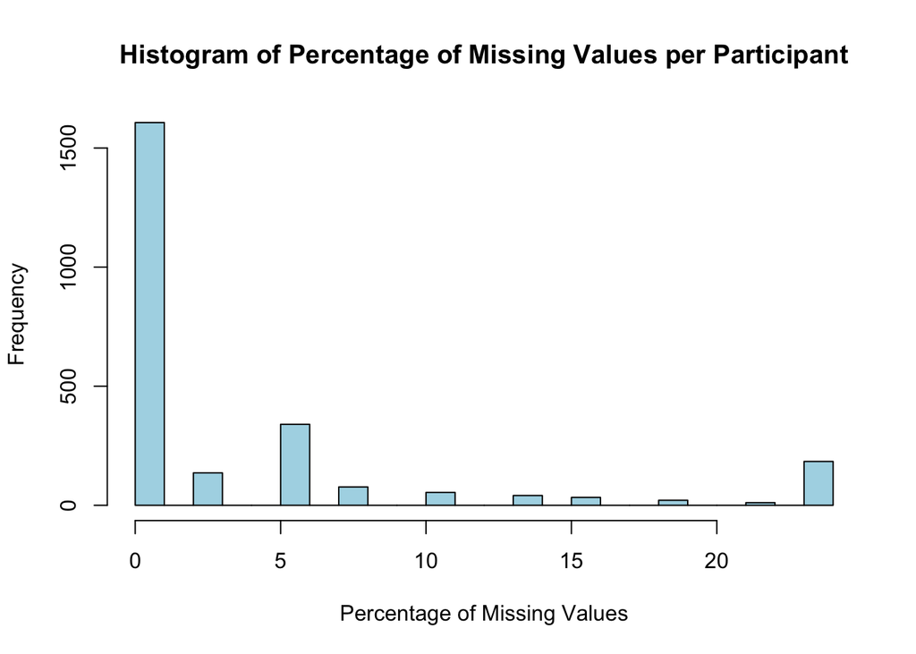

```r
#Check proportion of NA values **by participants**

percent_na_rows <- apply(data, 1, function(row) sum(is.na(row)) / length(row) * 100)

# Create a histogram of the percentage of missing values per participant

hist(
  percent_na_rows,
  breaks = 30,
  main = "Histogram of Percentage of Missing Values per Participant",
  xlab = "Percentage of Missing Values",
  ylab = "Frequency",
  col = "lightblue",
  border = "black"
)
```

We can observe that after dropping the participants (rows) without a valid `mortstat` value (0 or 1) AND selecting for participants that are greater than 50 years old, a total of 2504 participants remained, and we have a reasonable proportion of NA values (by predictors), except for the column of `BPXSY1` and `BPXDI1`, which slightly exceeded 26%. These two columns stand for **“Systolic Blood Pressure”** and **“Diastolic Blood Pressure”** respectively, I argue that these percentages are feasible for further data imputation, so that there is no further need to drop any NA’s from the current data set.

### Data Imputation

Here, for the variables `BPXSY1` and `BPXDI1`, I first divided the participants into two groups based on mortality statuses (0 or 1), then I perform imputation of these two variables separately by filling the NA values with **the median value of that group**. This is because participants who died or did not die may have a difference in some key vital signs (such as blood pressure), so performing imputation after separating the data will help to represent the distribution of the true population. My strategy will also apply to the rest of the **continuous variables with NA values** in this data frame, including `LBXRDW` (Red cell distribution width (%)), `BPXML1` (Maximum inflation levels), `BMXBMI` (Body Mass Index), and `BMXWAIST` (Waist circumference).

For the rest variables with NA values (both categorical and binary), I will impute the variables based on a **“majority rule”** of responses from the participants. This applies to variables `HSD010`, `VIQ200`, and `BPXPULS`. Still, my imputation will be carried out **after** separating participants based on mortality statuses.

```r
library(dplyr)

alive_group <- data %>% filter(mortstat == 0)
deceased_group <- data %>% filter(mortstat == 1)

continuous_vars <- c("RIDAGEYR", "BPXSY1", "BPXDI1", "LBXRDW", "BPXML1", "BMXBMI", "BMXWAIST")

categorical_vars <- c("HSD010", "VIQ200", "BPXPULS") # Categorical variables with a missing values

# Noticed that directly converting to `numeric variable` causes some issue in factor levels and `labels`, so need to convert to character first

for (var in continuous_vars) {
  alive_group[[var]] <- as.numeric(as.character(alive_group[[var]]))
  deceased_group[[var]] <- as.numeric(as.character(deceased_group[[var]]))
}

# Use median value to impute missing NA's among continuous variables
impute_median <- function(data, variables) {
  for (var in variables) {
    data[[var]][is.na(data[[var]])] <- median(data[[var]], na.rm = TRUE)
  }
  return(data)
}

alive_group <- impute_median(alive_group, continuous_vars)
deceased_group <- impute_median(deceased_group, continuous_vars)

# Use majority value to impute missing NA's among categorical variables
impute_majority_rule <- function(data, variables) {
  for (var in variables) {
    majority_value <- names(sort(table(data[[var]]), decreasing = TRUE))[1]
    data[[var]][is.na(data[[var]])] <- majority_value
  }
  return(data)
}

alive_group <- impute_majority_rule(alive_group, categorical_vars)
deceased_group <- impute_majority_rule(deceased_group, categorical_vars)

imputed_data <- rbind(alive_group, deceased_group)
summary(imputed_data)
```

```
##       SEQN         mortstat         RIDAGEYR     RIAGENDR BPQ010   BPQ060
##  21009  :   1   Min.   :0.0000   Min.   :50.00   1:1213   1:2109   1:2157
##  21010  :   1   1st Qu.:0.0000   1st Qu.:60.00   2:1291   2: 211   2: 264
##  21012  :   1   Median :0.0000   Median :68.00            3:  87   9:  83
##  21015  :   1   Mean   :0.2716   Mean   :68.04            4:  86
##  21019  :   1   3rd Qu.:1.0000   3rd Qu.:77.00            5:   6
##  21020  :   1   Max.   :1.0000   Max.   :85.00            9:   5
##  (Other):2498
##  DIQ010   DIQ050   DIQ090   MCQ010   MCQ053   MCQ160A  MCQ160B  MCQ160K
##  1: 466   1: 114   1: 117   1: 272   1: 114   1:1157   1: 185   1: 207
##  2:1983   2:2390   2:2383   2:2229   2:2388   2:1338   2:2300   2:2290
##  3:  54            9:   4   9:   3   7:   0   9:   9   9:  19   9:   7
##  9:   1                              9:   2
##
##
##
##  MCQ160L     BMXWAIST     MCQ160M  MCQ220   MCQ245A  MCQ250A  MCQ250B  MCQ250C
##  1: 108   Min.   : 61.8   1: 367   1: 411   1: 828   1:1167   1: 326   1: 453
##  2:2390   1st Qu.: 92.7   2:2128   2:2089   2:1676   2:1275   2:2121   2:1988
##  9:   6   Median :100.0   9:   9   9:   4            9:  62   9:  57   9:  63
##           Mean   :100.6
##           3rd Qu.:107.3
##           Max.   :157.1
##
##  MCQ250E  MCQ250F  MCQ250G  MCQ265   SSQ011   SSQ051   WHQ030   WHQ040
##  1: 352   1: 581   1: 309   1: 319   1:2310   1:1869   1:1339   1: 133
##  2:2045   2:1773   2:2087   2:2098   2: 154   2: 537   2: 126   2:1420
##  9: 107   9: 150   9: 108   7:   0   3:  36   3:  71   3:1030   3: 943
##                             9:  87   9:   4   9:  27   7:   0   7:   0
##                                                        9:   9   9:   8
##
##
##      LBXRDW      HSD010   BPXPULS      BPXML1      VIQ200       BMXBMI
##  Min.   :11.00   1: 198   1:2245   Min.   :120.0   1: 420   Min.   :14.70
##  1st Qu.:12.40   2: 511   2: 259   1st Qu.:150.0   2:2076   1st Qu.:24.86
##  Median :12.70   3:1128            Median :170.0   9:   8   Median :27.48
##  Mean   :13.01   4: 521            Mean   :167.9            Mean   :28.38
##  3rd Qu.:13.30   5: 146            3rd Qu.:180.0            3rd Qu.:30.96
##  Max.   :22.40                     Max.   :290.0            Max.   :58.58
##
##      BPXSY1          BPXDI1
##  Min.   : 80.0   Min.   :  0.00
##  1st Qu.:126.0   1st Qu.: 66.00
##  Median :134.0   Median : 72.00
##  Mean   :137.6   Mean   : 69.73
##  3rd Qu.:144.0   3rd Qu.: 76.00
##  Max.   :240.0   Max.   :120.00
##
```

```r
percent_na <- sapply(imputed_data, function(col) sum(is.na(col)) / length(col) * 100)
cat("Percentage of NA values after imputation:\n")
```

```
## Percentage of NA values after imputation:
```

```r
print(percent_na)
```

```
##     SEQN mortstat RIDAGEYR RIAGENDR   BPQ010   BPQ060   DIQ010   DIQ050
##        0        0        0        0        0        0        0        0
##   DIQ090   MCQ010   MCQ053  MCQ160A  MCQ160B  MCQ160K  MCQ160L BMXWAIST
##        0        0        0        0        0        0        0        0
##  MCQ160M   MCQ220  MCQ245A  MCQ250A  MCQ250B  MCQ250C  MCQ250E  MCQ250F
##        0        0        0        0        0        0        0        0
##  MCQ250G   MCQ265   SSQ011   SSQ051   WHQ030   WHQ040   LBXRDW   HSD010
##        0        0        0        0        0        0        0        0
##  BPXPULS   BPXML1   VIQ200   BMXBMI   BPXSY1   BPXDI1
##        0        0        0        0        0        0
```

### Data Encoding & Scaling

Next, we consider the necessity for performing one-hot encoding for categorical variables and min-max scaling for continuous variables. I argue that one-hot encoding is necessary for some of the model if it is necessary for us to include categorical variables: some categorical variables such as `WHQ040` and `BPQ010` have multiple levels with some different ordinal relationships. E.g., for `BPQ010`, the levels are determined based on increasing time intervals (short time period –> long time period), while for `WHQ040`, the levels are determined based on whether or not people tend to weight more, less, or stay the same. The order of variable levels differs between different categorical variables, and that’s why I think one-hot encode all the categorical variables in the data set is useful in some cases.

For data scaling, noticing that some outliers exist in the data set (such as the maximum of `BMXBMI` equals to 58.58 and minimum of `BPXDI1` equals to 0.00), it might not be a good option to perform min-max scaling because the transformed data will be biased by the outlier(s). So I performed standardization to adjust for different units and spreads of continuous variables.

```r
encoded_data <- imputed_data
encoded_data$SEQN <- NULL  # Remove the SEQN column, useless

# Remove zero columns
encoded_data <- encoded_data[, colSums(encoded_data != 0) > 0]

cat("Dimension of the data set after one-hot encoding and removing zero columns:\n")
```

```
## Dimension of the data set after one-hot encoding and removing zero columns:
```

```r
dim(encoded_data)
```

```
## [1] 2504   37
```

```r
# Min-max scaling
# encoded_data <- encoded_data %>%
#   mutate(across(all_of(continuous_vars), ~ (. - min(.)) / (max(.) - min(.))))

# Standardization
encoded_data[continuous_vars] <- scale(encoded_data[continuous_vars])


summary(encoded_data)
```

```
##     mortstat         RIDAGEYR         RIAGENDR BPQ010   BPQ060   DIQ010
##  Min.   :0.0000   Min.   :-1.676479   1:1213   1:2109   1:2157   1: 466
##  1st Qu.:0.0000   1st Qu.:-0.747184   2:1291   2: 211   2: 264   2:1983
##  Median :0.0000   Median :-0.003748            3:  87   9:  83   3:  54
##  Mean   :0.2716   Mean   : 0.000000            4:  86            9:   1
##  3rd Qu.:1.0000   3rd Qu.: 0.832617            5:   6
##  Max.   :1.0000   Max.   : 1.576053            9:   5
##  DIQ050   DIQ090   MCQ010   MCQ053   MCQ160A  MCQ160B  MCQ160K  MCQ160L
##  1: 114   1: 117   1: 272   1: 114   1:1157   1: 185   1: 207   1: 108
##  2:2390   2:2383   2:2229   2:2388   2:1338   2:2300   2:2290   2:2390
##           9:   4   9:   3   7:   0   9:   9   9:  19   9:   7   9:   6
##                             9:   2
##
##
##     BMXWAIST        MCQ160M  MCQ220   MCQ245A  MCQ250A  MCQ250B  MCQ250C
##  Min.   :-3.04490   1: 367   1: 411   1: 828   1:1167   1: 326   1: 453
##  1st Qu.:-0.62116   2:2128   2:2089   2:1676   2:1275   2:2121   2:1988
##  Median :-0.04856   9:   9   9:   4            9:  62   9:  57   9:  63
##  Mean   : 0.00000
##  3rd Qu.: 0.52600
##  Max.   : 4.43027
##  MCQ250E  MCQ250F  MCQ250G  MCQ265   SSQ011   SSQ051   WHQ030   WHQ040
##  1: 352   1: 581   1: 309   1: 319   1:2310   1:1869   1:1339   1: 133
##  2:2045   2:1773   2:2087   2:2098   2: 154   2: 537   2: 126   2:1420
##  9: 107   9: 150   9: 108   7:   0   3:  36   3:  71   3:1030   3: 943
##                             9:  87   9:   4   9:  27   7:   0   7:   0
##                                                        9:   9   9:   8
##
##      LBXRDW        HSD010   BPXPULS      BPXML1         VIQ200
##  Min.   :-1.8384   1: 198   1:2245   Min.   :-2.14775   1: 420
##  1st Qu.:-0.5563   2: 511   2: 259   1st Qu.:-0.80292   2:2076
##  Median :-0.2816   3:1128            Median : 0.09363   9:   8
##  Mean   : 0.0000   4: 521            Mean   : 0.00000
##  3rd Qu.: 0.2679   5: 146            3rd Qu.: 0.54190
##  Max.   : 8.6014                     Max.   : 5.47294
##      BMXBMI            BPXSY1            BPXDI1
##  Min.   :-2.4772   Min.   :-2.8644   Min.   :-5.1490
##  1st Qu.:-0.6367   1st Qu.:-0.5775   1st Qu.:-0.2754
##  Median :-0.1621   Median :-0.1797   Median : 0.1676
##  Mean   : 0.0000   Mean   : 0.0000   Mean   : 0.0000
##  3rd Qu.: 0.4687   3rd Qu.: 0.3174   3rd Qu.: 0.4630
##  Max.   : 5.4715   Max.   : 5.0902   Max.   : 3.7120
```

### Train Test Split

Next step I performed train-test split to separate the data into two groups, train set and test set. I used a standard 80/20 split. It is worth noting that I observed the **imbalanced nature** of `mortstat` variable (73% 0’s, ~27% 1’s), and to account for this, I first separated the participants into two groups based on their alive/deceased status, and then randomly split 80/20 within each group, finally combined the two subgroup together into one big train and/or test data set. This **ensures that we observe a similar proportion of alive and deceased individuals within both train and test set**, with the specific proportions recorded below:

```r
library(caret)
```

```r
library(ggplot2)
library(reshape2)
library(gridExtra)
alive_group <- encoded_data %>% filter(mortstat == 0)
deceased_group <- encoded_data %>% filter(mortstat == 1)

set.seed(123456)

alive_train_ind <- sample(seq_len(nrow(alive_group)), size = floor(0.8 * nrow(alive_group)))
alive_train <- alive_group[alive_train_ind, ]
alive_test <- alive_group[-alive_train_ind, ]

deceased_train_ind <- sample(seq_len(nrow(deceased_group)), size = floor(0.8 * nrow(deceased_group)))
deceased_train <- deceased_group[deceased_train_ind, ]
deceased_test <- deceased_group[-deceased_train_ind, ]

train_set <- bind_rows(alive_train, deceased_train)
test_set <- bind_rows(alive_test, deceased_test)

print(summary(train_set))
```

```
##     mortstat         RIDAGEYR          RIAGENDR BPQ010   BPQ060   DIQ010
##  Min.   :0.0000   Min.   :-1.6764792   1: 970   1:1688   1:1727   1: 385
##  1st Qu.:0.0000   1st Qu.:-0.7471843   2:1033   2: 166   2: 206   2:1577
##  Median :0.0000   Median :-0.0037484            3:  68   9:  70   3:  40
##  Mean   :0.2716   Mean   : 0.0004736            4:  71            9:   1
##  3rd Qu.:1.0000   3rd Qu.: 0.8326171            5:   6
##  Max.   :1.0000   Max.   : 1.5760530            9:   4
##  DIQ050   DIQ090   MCQ010   MCQ053   MCQ160A  MCQ160B  MCQ160K  MCQ160L
##  1:  88   1:  92   1: 222   1:  90   1: 933   1: 139   1: 167   1:  90
##  2:1915   2:1907   2:1778   2:1911   2:1062   2:1850   2:1831   2:1910
##           9:   4   9:   3   7:   0   9:   8   9:  14   9:   5   9:   3
##                             9:   2
##
##
##     BMXWAIST         MCQ160M  MCQ220   MCQ245A  MCQ250A  MCQ250B  MCQ250C
##  Min.   :-3.044899   1: 292   1: 330   1: 653   1: 938   1: 267   1: 366
##  1st Qu.:-0.644688   2:1703   2:1670   2:1350   2:1016   2:1691   2:1585
##  Median :-0.040713   9:   8   9:   3            9:  49   9:  45   9:  52
##  Mean   : 0.001686
##  3rd Qu.: 0.555418
##  Max.   : 4.218485
##  MCQ250E  MCQ250F  MCQ250G  MCQ265   SSQ011   SSQ051   WHQ030   WHQ040
##  1: 288   1: 463   1: 250   1: 242   1:1853   1:1505   1:1074   1: 102
##  2:1627   2:1423   2:1666   2:1688   2: 121   2: 417   2: 101   2:1141
##  9:  88   9: 117   9:  87   7:   0   3:  25   3:  60   3: 823   3: 756
##                             9:  73   9:   4   9:  21   7:   0   7:   0
##                                                        9:   5   9:   4
##
##      LBXRDW          HSD010  BPXPULS      BPXML1          VIQ200
##  Min.   :-1.838386   1:152   1:1788   Min.   :-2.147749   1: 340
##  1st Qu.:-0.556303   2:412   2: 215   1st Qu.:-0.802922   2:1657
##  Median :-0.281571   3:884            Median : 0.093629   9:   6
##  Mean   : 0.006557   4:436            Mean   :-0.003053
##  3rd Qu.: 0.267893   5:119            3rd Qu.: 0.541905
##  Max.   : 8.601432                    Max.   : 5.472939
##      BMXBMI              BPXSY1              BPXDI1
##  Min.   :-2.477156   Min.   :-2.864403   Min.   :-5.148972
##  1st Qu.:-0.653938   1st Qu.:-0.577455   1st Qu.:-0.275431
##  Median :-0.145828   Median :-0.179725   Median : 0.167618
##  Mean   : 0.006734   Mean   : 0.005389   Mean   : 0.000101
##  3rd Qu.: 0.489082   3rd Qu.: 0.416870   3rd Qu.: 0.462984
##  Max.   : 5.221478   Max.   : 5.090198   Max.   : 3.712011
```

```r
print(summary(test_set))
```

```
##     mortstat         RIDAGEYR         RIAGENDR BPQ010  BPQ060  DIQ010  DIQ050
##  Min.   :0.0000   Min.   :-1.676479   1:243    1:421   1:430   1: 81   1: 26
##  1st Qu.:0.0000   1st Qu.:-0.747184   2:258    2: 45   2: 58   2:406   2:475
##  Median :0.0000   Median :-0.003748            3: 19   9: 13   3: 14
##  Mean   :0.2715   Mean   :-0.001894            4: 15           9:  0
##  3rd Qu.:1.0000   3rd Qu.: 0.925547            5:  0
##  Max.   :1.0000   Max.   : 1.576053            9:  1
##  DIQ090  MCQ010  MCQ053  MCQ160A MCQ160B MCQ160K MCQ160L    BMXWAIST
##  1: 25   1: 50   1: 24   1:224   1: 46   1: 40   1: 18   Min.   :-2.691927
##  2:476   2:451   2:477   2:276   2:450   2:459   2:480   1st Qu.:-0.566250
##  9:  0   9:  0   7:  0   9:  1   9:  5   9:  2   9:  3   Median :-0.064245
##                  9:  0                                   Mean   :-0.006739
##                                                          3rd Qu.: 0.445604
##                                                          Max.   : 4.430269
##  MCQ160M MCQ220  MCQ245A MCQ250A MCQ250B MCQ250C MCQ250E MCQ250F MCQ250G
##  1: 75   1: 81   1:175   1:229   1: 59   1: 87   1: 64   1:118   1: 59
##  2:425   2:419   2:326   2:259   2:430   2:403   2:418   2:350   2:421
##  9:  1   9:  1           9: 13   9: 12   9: 11   9: 19   9: 33   9: 21
##
##
##
##  MCQ265  SSQ011  SSQ051  WHQ030  WHQ040      LBXRDW         HSD010  BPXPULS
##  1: 77   1:457   1:364   1:265   1: 31   Min.   :-1.65523   1: 46   1:457
##  2:410   2: 33   2:120   2: 25   2:279   1st Qu.:-0.55630   2: 99   2: 44
##  7:  0   3: 11   3: 11   3:207   3:187   Median :-0.18999   3:244
##  9: 14   9:  0   9:  6   7:  0   7:  0   Mean   :-0.02621   4: 85
##                          9:  4   9:  4   3rd Qu.: 0.26789   5: 27
##                                          Max.   : 5.02991
##      BPXML1         VIQ200      BMXBMI             BPXSY1
##  Min.   :-2.14775   1: 80   Min.   :-2.17283   Min.   :-2.46667
##  1st Qu.:-0.35465   2:419   1st Qu.:-0.58782   1st Qu.:-0.47802
##  Median : 0.09363   9:  2   Median :-0.20380   Median :-0.17972
##  Mean   : 0.01221           Mean   :-0.02692   Mean   :-0.02155
##  3rd Qu.: 0.54190           3rd Qu.: 0.35956   3rd Qu.: 0.11857
##  Max.   : 4.12811           Max.   : 5.47146   Max.   : 4.19531
##      BPXDI1
##  Min.   :-5.148972
##  1st Qu.:-0.275431
##  Median : 0.167618
##  Mean   :-0.000405
##  3rd Qu.: 0.315301
##  Max.   : 3.121279
```

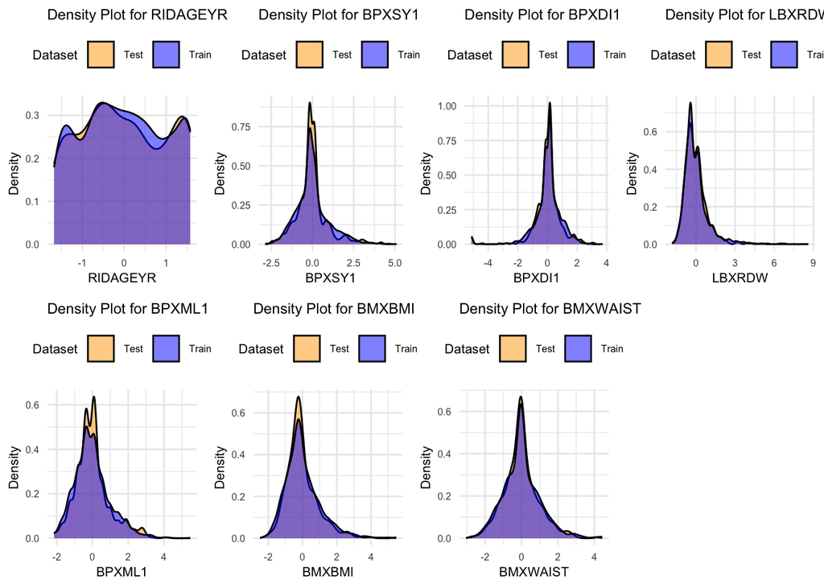

```r
continuous_vars <- c("RIDAGEYR", "BPXSY1", "BPXDI1", "LBXRDW", "BPXML1", "BMXBMI", "BMXWAIST")

train_set$Dataset <- "Train"
test_set$Dataset <- "Test"

# Combine the train and test sets for continuous variables
combined_set <- rbind(train_set, test_set)

plots <- list()

for (var in continuous_vars) {
  # Create a density plot for the current variable
  p <- ggplot(combined_set, aes_string(x = var, fill = "Dataset")) +
    geom_density(alpha = 0.5) +  # Overlay densities
    labs(title = paste("Density Plot for", var), x = var, y = "Density") +
    theme_minimal() +
    scale_fill_manual(values = c("Train" = "blue", "Test" = "orange")) +
    theme(legend.position = "top",
      plot.title = element_text(size = 9),
      axis.title = element_text(size = 8),
      axis.text = element_text(size = 6),
      legend.text = element_text(size = 6),
      legend.title = element_text(size = 8) )
    plots[[var]] <- p
}
do.call(grid.arrange, c(plots, ncol = 4, nrow = 2))
```

```r
cat("Training Set Mortality Status Distribution:\n")
```

```
## Training Set Mortality Status Distribution:
```

```r
print(table(train_set$mortstat))
```

```
##
##    0    1
## 1459  544
```

```r
cat("Test Set Mortality Status Distribution:\n")
```

```
## Test Set Mortality Status Distribution:
```

```r
print(table(test_set$mortstat))
```

```
##
##   0   1
## 365 136
```

```r
# Display the proportion of alive and deceased in train and test sets
cat("Proportion of Alive and Deceased in Training Set:\n")
```

```
## Proportion of Alive and Deceased in Training Set:
```

```r
print(prop.table(table(train_set$mortstat)))
```

```
##
##         0         1
## 0.7284074 0.2715926
```

```r
cat("Proportion of Alive and Deceased in Test Set:\n")
```

```
## Proportion of Alive and Deceased in Test Set:
```

```r
print(prop.table(table(test_set$mortstat)))
```

```
##
##         0         1
## 0.7285429 0.2714571
```

```r
train_set <- train_set %>%
  mutate(mortstat = as.numeric(mortstat))

test_set <- test_set %>%
  mutate(mortstat = as.numeric(mortstat))

# Remove the `Dataset` variables after generating the plot
train_set$Dataset <- NULL
test_set$Dataset <- NULL
```

Based on the output statistics and the density plot describing the distribution of the continuous variable after standardization, we can observe a relatively consistent distribution among all variables, which suggest that we did a relatively well train-test split overall.

### How to quantify the model performance?

A standard way is to do some calculations based on confusion matrices and infer relevant statistics. R’s `caret` library `confusionMatrix` function generates a list of statistics based on predicted vs. actual classes.

**The major issue is: Do we concern more about sensitivity or specificity?** Sensitivity measures how well a model correctly detects individuals with outcome of interest (in our case, die) from the entire population; specificity, on the other hand, is the ability for the model to correctly classify an individual without outcome of interest (in our case, alive).

Which one do we care more about? Considering that we build our model to predict individuals with potential mortality outcomes, and grounded on the common sense that we want to avoid deaths (generally) as much as we can, I argue that **we care more about the sensitivity of the prediction model**. That is, when we finally utilize the model, if we observe a positive outcome (class “1”, deceased), we want to have a compelling argument that the individual has high risk of dying.

Based on my argument, for the models tested below, **I** **always prioritize model’s sensitivity**; if multiple models have similar sensitivity, then I proceed and prioritize the one with better accuracy.

## Model Construction & Evaluation

### Logistic Regression

To build a prediction model using logistic regression and select the best set of variables, we first fit the model using the **scaled and not-encoded raw data**, and we will perform variable selection after that. Note that logistic regression automatically encodes the data, which can be seen from the model summary.

```r
logistic_model <- glm(mortstat ~ ., data = train_set, family = binomial)

summary(logistic_model)
```

```
##
## Call:
## glm(formula = mortstat ~ ., family = binomial, data = train_set)
##
## Coefficients:
##               Estimate Std. Error z value Pr(>|z|)
## (Intercept)  -0.412982   0.974403  -0.424 0.671689
## RIDAGEYR      1.141205   0.100082  11.403  < 2e-16 ***
## RIAGENDR2    -0.569427   0.153545  -3.709 0.000208 ***
## BPQ0102       0.150379   0.259098   0.580 0.561650
## BPQ0103      -0.285172   0.459403  -0.621 0.534768
## BPQ0104      -0.053353   0.419523  -0.127 0.898802
## BPQ0105       1.761428   1.043354   1.688 0.091366 .
## BPQ0109      -0.482956   1.475145  -0.327 0.743368
## BPQ0602       0.097361   0.233667   0.417 0.676924
## BPQ0609       0.200491   0.338728   0.592 0.553922
## DIQ0102      -0.107334   0.182502  -0.588 0.556450
## DIQ0103      -0.295744   0.467617  -0.632 0.527093
## DIQ0109      16.669591 882.743588   0.019 0.984934
## DIQ0502      -0.555249   0.314703  -1.764 0.077672 .
## DIQ0902      -0.918112   0.279932  -3.280 0.001039 **
## DIQ0909       1.227735   1.546005   0.794 0.427118
## MCQ0102      -0.049969   0.214152  -0.233 0.815503
## MCQ0109     -13.222055 459.968347  -0.029 0.977068
## MCQ0532       0.151687   0.283614   0.535 0.592763
## MCQ0539      -0.447094   2.139311  -0.209 0.834456
## MCQ160A2     -0.104314   0.136755  -0.763 0.445595
## MCQ160A9     -0.693684   1.235044  -0.562 0.574342
## MCQ160B2     -0.591112   0.233262  -2.534 0.011273 *
## MCQ160B9     -1.339316   0.829258  -1.615 0.106294
## MCQ160K2     -0.223375   0.237277  -0.941 0.346494
## MCQ160K9     -0.131922   1.886688  -0.070 0.944255
## MCQ160L2     -0.147378   0.322846  -0.456 0.648034
## MCQ160L9      2.259997   1.642297   1.376 0.168785
## BMXWAIST      0.178791   0.124014   1.442 0.149388
## MCQ160M2     -0.070574   0.182018  -0.388 0.698215
## MCQ160M9      0.820184   1.022991   0.802 0.422697
## MCQ2202      -0.306573   0.158620  -1.933 0.053267 .
## MCQ2209       1.011323   1.382510   0.732 0.464466
## MCQ245A2      0.288695   0.191624   1.507 0.131921
```

[output cut: 33 more lines]

```
## VIQ2002       0.107610   0.159285   0.676 0.499308
## VIQ2009       1.714825   1.157603   1.481 0.138511
## BMXBMI       -0.021651   0.129671  -0.167 0.867396
## BPXSY1        0.198643   0.106262   1.869 0.061572 .
## BPXDI1       -0.064625   0.062063  -1.041 0.297745
## ---
## Signif. codes:  0 '***' 0.001 '**' 0.01 '*' 0.05 '.' 0.1 ' ' 1
##
## (Dispersion parameter for binomial family taken to be 1)
##
##     Null deviance: 2342.9  on 2002  degrees of freedom
## Residual deviance: 1625.7  on 1931  degrees of freedom
## AIC: 1769.7
##
## Number of Fisher Scoring iterations: 13
```

```r
test_pred <- predict(logistic_model, newdata = test_set, type = "response")
test_pred_binary <- ifelse(test_pred >= 0.5, 1, 0) # Convert the final probabilities to binary classes


rmse_logistic <- sqrt(mean((test_set$mortstat - test_pred)^2))

cat("Root Mean Squared Error (RMSE) on the test set for logistic regression:", rmse_logistic, "\n\n")
```

```
## Root Mean Squared Error (RMSE) on the test set for logistic regression: 0.382322
```

```r
confusion_matrix_logistic <- confusionMatrix(factor(test_pred_binary), factor(test_set$mortstat), positive = "1") # Set the positive class to 1 so that

print(confusion_matrix_logistic)
```

```
## Confusion Matrix and Statistics
##
##           Reference
## Prediction   0   1
##          0 327  69
##          1  38  67
##
##                Accuracy : 0.7864
##                  95% CI : (0.7479, 0.8215)
##     No Information Rate : 0.7285
##     P-Value [Acc > NIR] : 0.001718
##
##                   Kappa : 0.4185
##
##  Mcnemar's Test P-Value : 0.003729
##
##             Sensitivity : 0.4926
##             Specificity : 0.8959
##          Pos Pred Value : 0.6381
##          Neg Pred Value : 0.8258
##              Prevalence : 0.2715
##          Detection Rate : 0.1337
##    Detection Prevalence : 0.2096
##       Balanced Accuracy : 0.6943
##
##        'Positive' Class : 1
##
```

From the summary of the un-optimized model, we can conclude that:

1. `RIDAGEYR` is a highly significant predictor based on the `glm` model; from the positive coefficient, we can infer that higher age (in years) is associated with higher odds of mortality.
2. `RIAGENDR2` is a significant predictor, which encodes for “Gender = Female”. The model outputs a negative log-odds estimate, thus indicating that being female is associated with reduced odds of mortality *compared to being a male*.
3. `LBXRDW` is a significant continuous predictor encodes for “Red cell distribution width (%)”. A positive log-odds estimate suggests that participants with a higher percentage of red cell distribution width may be associated with higher odds of mortality compared to those falls in normal / low range.
4. `HSD0102`, `HSD0103`, `HSD0104`, and `HSD0105` are predictors with increased significance levels. These variables indicates the “General health condition” of the participants. It ranges from `HSD0101` to `HSD0105` indicating “Excellent” to “Poor” conditions, with `HSD0107` stands for “refused” and `HSD0109` as “don’t know” (zero observations). From the increasing significance level and positive log-odds estimate from `HSD0101` (baseline) to `HSD0105` (poor condition), we can interpret that the extent that participants self report negative health condition serves as a positive predictor of their mortality status.
5. The overall raw model accuracy is 78.64%, which is **significantly better than the NIR**. This suggests that it performed significantly better than the baseline. The model’s sensitivity is only 49.26%, which suggests that it struggles to detect died individuals from the whole population. We could blame the low sensitivity (compared to specificity) to two reasons:
   1. Imbalanced data, as there are only ~27% of deceased individuals compared to ~73% alive ones, thus the model has fewer data to pick up the signals. As a matter of fact, overall speaking, **the majority of the models tested in this project had lower sensitivity than the specificity**;
   2. The over-simplicity of the logistic model, thus the overall performance is affected.

Based on the raw model, we selected the top significant variables `RIDAGEYR`, `RIAGENDR`, `LBXRDW`, and `HSD010` as the updated “optimized” model for logistic regression.

```r
logistic_model <- glm(mortstat ~ RIDAGEYR + RIAGENDR + LBXRDW + HSD010, data = train_set, family = binomial)

summary(logistic_model)
```

```
##
## Call:
## glm(formula = mortstat ~ RIDAGEYR + RIAGENDR + LBXRDW + HSD010,
##     family = binomial, data = train_set)
##
## Coefficients:
##             Estimate Std. Error z value Pr(>|z|)
## (Intercept) -2.09954    0.28392  -7.395 1.42e-13 ***
## RIDAGEYR     1.22384    0.07263  16.850  < 2e-16 ***
## RIAGENDR2   -0.61054    0.12036  -5.072 3.93e-07 ***
## LBXRDW       0.51111    0.06087   8.396  < 2e-16 ***
## HSD0102      0.58509    0.31364   1.865 0.062117 .
## HSD0103      1.12391    0.29106   3.861 0.000113 ***
## HSD0104      1.16566    0.30412   3.833 0.000127 ***
## HSD0105      2.09605    0.36079   5.810 6.26e-09 ***
## ---
## Signif. codes:  0 '***' 0.001 '**' 0.01 '*' 0.05 '.' 0.1 ' ' 1
##
## (Dispersion parameter for binomial family taken to be 1)
##
##     Null deviance: 2342.9  on 2002  degrees of freedom
## Residual deviance: 1746.7  on 1995  degrees of freedom
## AIC: 1762.7
##
## Number of Fisher Scoring iterations: 5
```

```r
test_pred <- predict(logistic_model, newdata = test_set, type = "response")
test_pred_binary <- ifelse(test_pred >= 0.5, 1, 0) # Convert the final probabilities to binary classes

rmse_logistic_best <- sqrt(mean((test_set$mortstat - test_pred)^2))

cat("Root Mean Squared Error (RMSE) on the test set for logistic regression:", rmse_logistic_best, "\n\n")
```

```
## Root Mean Squared Error (RMSE) on the test set for logistic regression: 0.3828173
```

```r
confusion_matrix_logistic_best <- confusionMatrix(factor(test_pred_binary), factor(test_set$mortstat), positive = "1") # Set the positive class to 1 so that the relevant statistics are correct

print(confusion_matrix_logistic_best)
```

```
## Confusion Matrix and Statistics
##
##           Reference
## Prediction   0   1
##          0 336  71
##          1  29  65
##
##                Accuracy : 0.8004
##                  95% CI : (0.7627, 0.8345)
##     No Information Rate : 0.7285
##     P-Value [Acc > NIR] : 0.0001205
##
##                   Kappa : 0.4412
##
##  Mcnemar's Test P-Value : 4.132e-05
##
##             Sensitivity : 0.4779
##             Specificity : 0.9205
##          Pos Pred Value : 0.6915
##          Neg Pred Value : 0.8256
##              Prevalence : 0.2715
##          Detection Rate : 0.1297
##    Detection Prevalence : 0.1876
##       Balanced Accuracy : 0.6992
##
##        'Positive' Class : 1
##
```

From the optimized model, we can see that the overall accuracy improve from 78.64% to 80.04%. However, the sensitivity decreased to 47.79% as the trade off for an increase in specificity. This suggest that the optimized model gets better in predicting alive individuals but performed worse in detecting deceased ones. This might suggest that logistic regression is not the best model to achieve our purpose.

### Lasso & Ridge Regression

For Lasso & Ridge regression, the models themselves does not auto-encode categorical variables. To remove the effect of ordinal relationships based on the nature of them (“1”, “2”, “3” for different meanings), I first performed one-hot encoding to encode each variable’s options into binary variables of “0”s and “1”s. Then I fit the model on the whole encoded & standardized data set **with cross-validation** for both Lasso and Ridge regression.

```r
# Load required packages
library(glmnet)
```

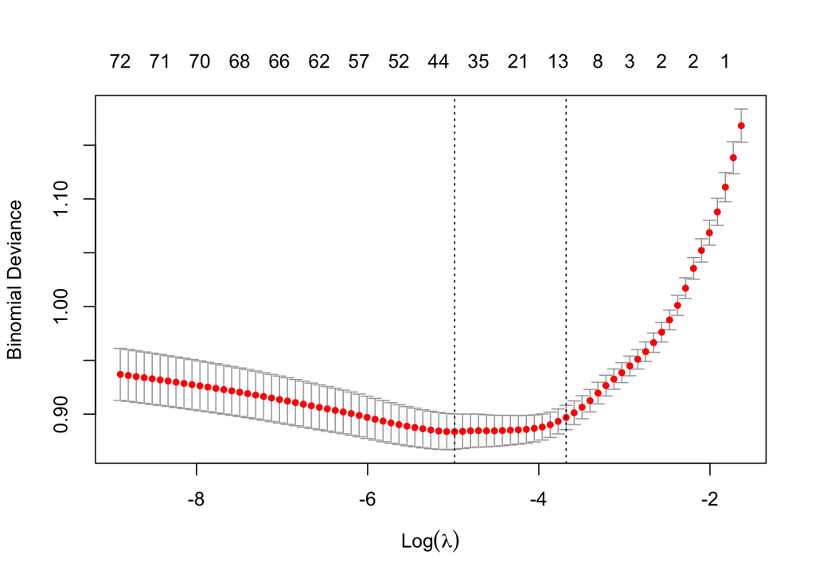

```r
# Lasso regression
x_train <- model.matrix(mortstat ~ . - 1, data = train_set)
x_test <- model.matrix(mortstat ~ . - 1, data = test_set)

# Extract the response variable
y_train <- train_set$mortstat
y_test <- test_set$mortstat

set.seed(123)
# lasso w/ cross validation
lasso_cv <- cv.glmnet(x_train, y_train, alpha = 1, family = "binomial")
lambda <- lasso_cv$lambda.min
plot(lasso_cv)
```

```r
lasso_model <- glmnet(x_train, y_train, alpha = 1, lambda = lambda, family = "binomial")

test_pred <- predict(lasso_model, s = lambda, newx = x_test, type = "response")
test_pred_binary <- ifelse(test_pred >= 0.5, 1, 0)

rmse_lasso <- sqrt(mean((y_test - test_pred)^2))
cat("Root Mean Squared Error (RMSE) of Lasso Regression:", rmse_lasso, "\n\n")
```

```
## Root Mean Squared Error (RMSE) of Lasso Regression: 0.3744254
```

```r
confusion_matrix_lasso <- confusionMatrix(factor(test_pred_binary), factor(y_test), positive = "1")
print(confusion_matrix_lasso)
```

```
## Confusion Matrix and Statistics
##
##           Reference
## Prediction   0   1
##          0 334  72
##          1  31  64
##
##                Accuracy : 0.7944
##                  95% CI : (0.7563, 0.829)
##     No Information Rate : 0.7285
##     P-Value [Acc > NIR] : 0.0004032
##
##                   Kappa : 0.4259
##
##  Mcnemar's Test P-Value : 8.104e-05
##
##             Sensitivity : 0.4706
##             Specificity : 0.9151
##          Pos Pred Value : 0.6737
##          Neg Pred Value : 0.8227
##              Prevalence : 0.2715
##          Detection Rate : 0.1277
##    Detection Prevalence : 0.1896
##       Balanced Accuracy : 0.6928
##
##        'Positive' Class : 1
##
```

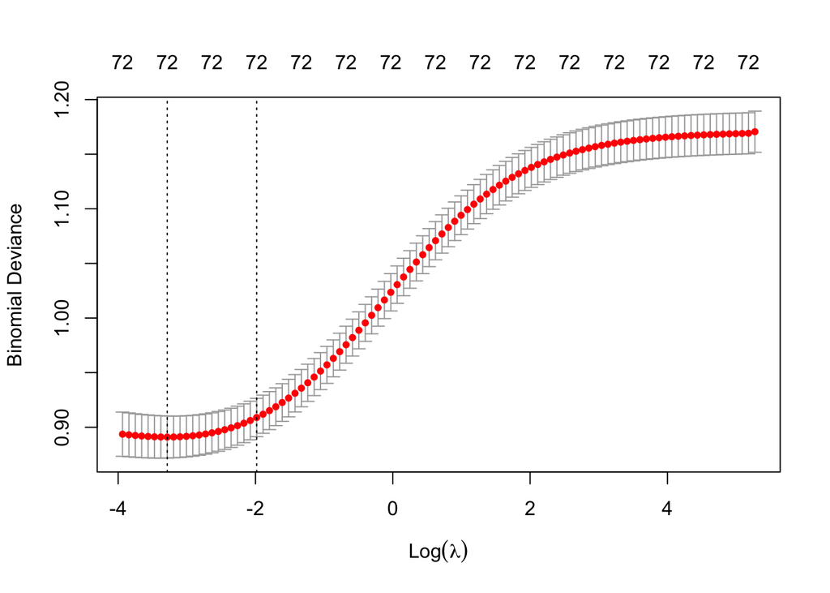

```r
# Examine coefficients
lasso_coefs <- coef(lasso_model)

# Extract non-zero coefs
non_zero_coefs_lasso <- lasso_coefs@x
non_zero_ind_lasso <- lasso_coefs@i + 1
variable_names_lasso <- lasso_coefs@Dimnames[[1]]

# Get the names of the variables corresponding to them
non_zero_vars_lasso <- variable_names_lasso[non_zero_ind_lasso]

lasso_results <- data.frame(
  Variable = non_zero_vars_lasso,
  Coefficient = non_zero_coefs_lasso
)

lasso_results_sorted <- lasso_results[order(-lasso_results$Coefficient), ]

# Ridge regression
ridge_cv <- cv.glmnet(x_train, y_train, alpha = 0, family = "binomial")
lambda <- ridge_cv$lambda.min
plot(ridge_cv)
```

```r
ridge_model <- glmnet(x_train, y_train, alpha = 0, lambda = lambda, family = "binomial")
summary(ridge_model)
```

```
##            Length Class     Mode
## a0          1     -none-    numeric
## beta       76     dgCMatrix S4
## df          1     -none-    numeric
## dim         2     -none-    numeric
## lambda      1     -none-    numeric
## dev.ratio   1     -none-    numeric
## nulldev     1     -none-    numeric
## npasses     1     -none-    numeric
## jerr        1     -none-    numeric
## offset      1     -none-    logical
## classnames  2     -none-    character
## call        6     -none-    call
## nobs        1     -none-    numeric
```

```r
# Make predictions using the Ridge model
test_pred <- predict(ridge_model, s = lambda, newx = x_test, type = "response")
test_pred_binary <- ifelse(test_pred >= 0.5, 1, 0)

rmse_ridge <- sqrt(mean((y_test - test_pred)^2))
cat("Root Mean Squared Error (RMSE) of Ridge Regression:", rmse_ridge, "\n\n")
```

```
## Root Mean Squared Error (RMSE) of Ridge Regression: 0.3765146
```

```r
# Generate confusion matrix for Ridge model
confusion_matrix_ridge <- confusionMatrix(factor(test_pred_binary), factor(y_test), positive = "1")
print(confusion_matrix_ridge)
```

```
## Confusion Matrix and Statistics
##
##           Reference
## Prediction   0   1
##          0 334  79
##          1  31  57
##
##                Accuracy : 0.7804
##                  95% CI : (0.7416, 0.8159)
##     No Information Rate : 0.7285
##     P-Value [Acc > NIR] : 0.004533
##
##                   Kappa : 0.3758
##
##  Mcnemar's Test P-Value : 7.42e-06
##
##             Sensitivity : 0.4191
##             Specificity : 0.9151
##          Pos Pred Value : 0.6477
##          Neg Pred Value : 0.8087
##              Prevalence : 0.2715
##          Detection Rate : 0.1138
##    Detection Prevalence : 0.1756
##       Balanced Accuracy : 0.6671
##
##        'Positive' Class : 1
##
```

```r
# Examine coefficients (ridge)
ridge_coefs <- coef(ridge_model)

# Extract non-zero coefs (ridge)
non_zero_coefs_ridge <- ridge_coefs@x
non_zero_ind_ridge <- ridge_coefs@i + 1
variable_names_ridge <- ridge_coefs@Dimnames[[1]]

# Get the names of the variables corresponding to them (ridge)
non_zero_vars_ridge <- variable_names_ridge[non_zero_ind_ridge]

ridge_results <- data.frame(
  Variable = non_zero_vars_ridge,
  Coefficient = non_zero_coefs_ridge
)

ridge_results_sorted <- ridge_results[order(-ridge_results$Coefficient), ]

cat("Lasso Regression Non-zero Coefficients in descending order:\n\n")
```

```
## Lasso Regression Non-zero Coefficients in descending order:
```

```r
# Top 5 and bottom 5 coefs for lasso
head(lasso_results_sorted, 5)
```

```
##    Variable Coefficient
## 6   DIQ0109   2.8642098
## 2  RIDAGEYR   1.0143710
## 39  VIQ2009   0.8833955
## 29  WHQ0302   0.8787160
## 38  HSD0105   0.7860729
```

```r
tail(lasso_results_sorted, 5)
```

```
##    Variable Coefficient
## 20 MCQ250A9  -0.4032988
## 11 MCQ160B2  -0.5056976
## 27  SSQ0119  -0.5095301
## 12 MCQ160B9  -0.5117675
## 8   DIQ0902  -0.7409459
```

```r
cat("Ridge Regression Non-zero Coefficients in descending order:\n\n")
```

```
## Ridge Regression Non-zero Coefficients in descending order:
```

```r
# Top 5 and bottom 5 coefs for lasso
head(ridge_results_sorted, 5)
```

```
##    Variable Coefficient
## 14  DIQ0109   3.3818489
## 61  WHQ0409   1.5634497
## 70  VIQ2009   1.3001714
## 29 MCQ160L9   1.2376648
## 8   BPQ0105   0.9915268
```

```r
tail(ridge_results_sorted, 5)
```

```
##    Variable Coefficient
## 16  DIQ0902  -0.6722840
## 25 MCQ160B9  -0.8631613
## 58  WHQ0309  -1.0624153
## 52  SSQ0119  -1.1764224
## 19  MCQ0109  -1.5744032
```

From the results, we can interpret that:

1. Lasso & Ridge achieved similar accuracy (79.44% & 78.04%) significantly greater than the baseline level, however they both struggled in terms of model sensitivity compared to either LDA/QDA or tree-based model which will be listed below.
2. Non-zero coefficient for Lasso & Ridge regression indicates the relative importance of the variables. The outputted data frame above subsetted for the top and bottom 5 variables with most positive/negative coefficients.

For the next step, I extracted all variables that have **non-zero coefficients from the full Lasso & Ridge regression model**, and re-run it again to observe improvements in prediction (if any):

```r
set.seed(123)
## Lasso
non_zero_vars_lasso <- non_zero_vars_lasso[non_zero_vars_lasso != "(Intercept)"] # Remove intercept

# Subset the training data again (lasso)
x_train_lasso_best <- x_train[, non_zero_vars_lasso]

# Fit the Lasso model again using only the selected variables (CV then regular)

cv_lasso_best <- cv.glmnet(x_train_lasso_best, y_train, alpha = 1, family = "binomial")
lambda <- cv_lasso_best$lambda.min

lasso_model_best <- glmnet(x_train_lasso_best, y_train, alpha = 1, lambda = lambda, family = "binomial")

test_pred <- predict(lasso_model_best, s = lambda, newx = x_test[, non_zero_vars_lasso], type = "response")
test_pred_binary <- ifelse(test_pred >= 0.5, 1, 0)

rmse_lasso_best <- sqrt(mean((y_test - test_pred)^2))
cat("Root Mean Squared Error (RMSE) of Lasso Regression (optimized):", rmse_lasso_best, "\n\n")
```

```
## Root Mean Squared Error (RMSE) of Lasso Regression (optimized): 0.3765353
```

```r
confusion_matrix_lasso_best <- confusionMatrix(factor(test_pred_binary), factor(y_test), positive = "1")
print(confusion_matrix_lasso_best)
```

```
## Confusion Matrix and Statistics
##
##           Reference
## Prediction   0   1
##          0 331  69
##          1  34  67
##
##                Accuracy : 0.7944
##                  95% CI : (0.7563, 0.829)
##     No Information Rate : 0.7285
##     P-Value [Acc > NIR] : 0.0004032
##
##                   Kappa : 0.4346
##
##  Mcnemar's Test P-Value : 0.0008078
##
##             Sensitivity : 0.4926
##             Specificity : 0.9068
##          Pos Pred Value : 0.6634
##          Neg Pred Value : 0.8275
##              Prevalence : 0.2715
##          Detection Rate : 0.1337
##    Detection Prevalence : 0.2016
##       Balanced Accuracy : 0.6997
##
##        'Positive' Class : 1
##
```

```r
## Ridge
non_zero_vars_ridge <- non_zero_vars_ridge[non_zero_vars_ridge != "(Intercept)"] # Remove intercept

# Subset the training data again (lasso)
x_train_ridge_best <- x_train[, non_zero_vars_ridge]

# Fit the Ridge model again using only the selected variables (CV then regular)

cv_ridge_best <- cv.glmnet(x_train_ridge_best, y_train, alpha = 1, family = "binomial")
lambda <- cv_ridge_best$lambda.min

ridge_model_best <- glmnet(x_train_ridge_best, y_train, alpha = 1, lambda = lambda, family = "binomial")

test_pred <- predict(ridge_model_best, s = lambda, newx = x_test[, non_zero_vars_ridge], type = "response")
test_pred_binary <- ifelse(test_pred >= 0.5, 1, 0)

rmse_ridge_best <- sqrt(mean((y_test - test_pred)^2))
cat("Root Mean Squared Error (RMSE) of Ridge Regression (optimized):", rmse_ridge_best, "\n\n")
```

```
## Root Mean Squared Error (RMSE) of Ridge Regression (optimized): 0.3744254
```

```r
confusion_matrix_ridge_best <- confusionMatrix(factor(test_pred_binary), factor(y_test), positive = "1")
print(confusion_matrix_ridge_best)
```

```
## Confusion Matrix and Statistics
##
##           Reference
## Prediction   0   1
##          0 334  72
##          1  31  64
##
##                Accuracy : 0.7944
##                  95% CI : (0.7563, 0.829)
##     No Information Rate : 0.7285
##     P-Value [Acc > NIR] : 0.0004032
##
##                   Kappa : 0.4259
##
##  Mcnemar's Test P-Value : 8.104e-05
##
##             Sensitivity : 0.4706
##             Specificity : 0.9151
##          Pos Pred Value : 0.6737
##          Neg Pred Value : 0.8227
##              Prevalence : 0.2715
##          Detection Rate : 0.1277
##    Detection Prevalence : 0.1896
##       Balanced Accuracy : 0.6928
##
##        'Positive' Class : 1
##
```

### Linear Discriminant Analysis (LDA) & Quadratic Discriminant Analysis (QDA)

Considering that LDA/QDA model assumes that the predictor variables **follow a multivariate normal distribution within each class**, then I argue that:

1. Including the categorical variables in the LDA/QDA model is not ideal, since first, it does not follow a continuous normal distribution, which violates the model assumption,
2. Secondly, it introduces too much co-linearity to the model, which increases the bias. These two facts are always true regardless of encoding the categorical variables or not, and co-linearity inflates especially when variable encoding introduces too many dummy variables.

Based on the above reasons, I exclude all categorical variables in the data set, and 7 continuous variables are left. These are: `RIDAGEYR` (Age in years), `BPXSY1` (Systolic blood pressure measured in $mm \ Hg$), `BPXDI1` (Diastolic blood pressure measured in $mm \ Hg$), `LBXRDW` (Red cell distribution width (%)), `BPXML1` (Maximum inflation levels measured in $mm \ Hg$), `BMXBMI` (Body Mass Index measured in $kg/m^2$), and `BMXWAIST` (Waist Circumference measured in $cm$).

How to decide which subset of these variables constitute the best model? Considering that 7 variables in total is not too large for brute-force searches, I built a function to output all the possible combinations of these 7 continuous variables, and then every combination was fitted to both LDA and QDA model, with final confusion matrix statistics (accuracy, sensitivity, and specificity) recorded. Considering that we are more interested about **sensitivity** of the data, the final data frame was outputted in a descending order based on model sensitivity.

```r
# Load required packages
library(MASS)
# Redefining variables
variables <- c("RIDAGEYR", "BPXSY1", "BPXDI1", "LBXRDW", "BPXML1", "BMXBMI", "BMXWAIST")

evaluate_model <- function(formula, train_data, test_data, test_response) {

  lda_model <- lda(as.formula(formula), data = train_data)

  predictions <- predict(lda_model, newdata = test_data)$class

  confusion_matrix <- table(Predicted = predictions, Actual = test_response)

  accuracy <- mean(predictions == test_response)
  sensitivity <- confusion_matrix[2, 2] / (confusion_matrix[2, 2] + confusion_matrix[1, 2])  # Sensitivity
  specificity <- confusion_matrix[1, 1] / (confusion_matrix[1, 1] + confusion_matrix[2, 1])  # Specificity

  return((list(accuracy = accuracy, sensitivity = sensitivity, specificity = specificity)))
}

variables_comb <- list()
for (i in 1:length(variables)) {
  variables_comb <- c(variables_comb, combn(variables, i, simplify = FALSE))
}

#print(variables_comb)

results <- data.frame(Combination = character(), Accuracy = numeric(), Specificity = numeric(), Sensitivity = numeric(), stringsAsFactors = FALSE)

# Loop over all combinations
for (comb in variables_comb) {
  formula <- paste("mortstat ~", paste(comb, collapse = " + "))

  metrics <- evaluate_model(formula, train_set, test_set, test_set$mortstat)

# Add the results to the dataframe
  results <- rbind(results, data.frame(Combination = formula,
                                       Accuracy = metrics$accuracy,
                                       Specificity = metrics$specificity,
                                       Sensitivity = metrics$sensitivity))
}

#print(results)

results_sorted <- results[order(-results$Sensitivity), ] # care about sensitivity
print(head(results_sorted, 6)) # Only top 6
```

```
##                                       Combination  Accuracy Specificity
## 8                    mortstat ~ RIDAGEYR + BPXSY1 0.7964072   0.8821918
## 29          mortstat ~ RIDAGEYR + BPXSY1 + BPXDI1 0.8003992   0.8876712
## 32          mortstat ~ RIDAGEYR + BPXSY1 + BMXBMI 0.7964072   0.8821918
## 66 mortstat ~ RIDAGEYR + BPXSY1 + BPXDI1 + BMXBMI 0.7984032   0.8849315
## 1                             mortstat ~ RIDAGEYR 0.8043912   0.8958904
## 9                    mortstat ~ RIDAGEYR + BPXDI1 0.8023952   0.8931507
##    Sensitivity
## 8    0.5661765
## 29   0.5661765
## 32   0.5661765
## 66   0.5661765
## 1    0.5588235
## 9    0.5588235
```

```r
# Load required packages
library(MASS)

lda_model <- lda(mortstat ~ RIDAGEYR + BPXSY1 + BPXDI1, data = train_set)

# Summary of the LDA model
print(lda_model)
```

```
## Call:
## lda(mortstat ~ RIDAGEYR + BPXSY1 + BPXDI1, data = train_set)
##
## Prior probabilities of groups:
##         0         1
## 0.7284074 0.2715926
##
## Group means:
##     RIDAGEYR      BPXSY1     BPXDI1
## 0 -0.2654669 -0.08615354  0.0874500
## 1  0.7137220  0.25090545 -0.2341669
##
## Coefficients of linear discriminants:
##                  LD1
## RIDAGEYR  1.07959003
## BPXSY1    0.07870467
## BPXDI1   -0.05413556
```

```r
# Make predictions on the test set using the optimal model
test_pred <- predict(lda_model, newdata = test_set)$class

rmse_lda <- sqrt(mean((as.numeric(test_pred) - as.numeric(test_set$mortstat))^2))
cat("Root Mean Squared Error (MSE) of Linear Discriminant Analysis (LDA):", rmse_lda, "\n\n")
```

```
## Root Mean Squared Error (MSE) of Linear Discriminant Analysis (LDA): 1.061953
```

```r
confusion_matrix_lda <- confusionMatrix(test_pred, factor(test_set$mortstat), positive = "1")
print("Confusion Matrix for LDA:")
```

```
## [1] "Confusion Matrix for LDA:"
```

```r
print(confusion_matrix_lda)
```

```
## Confusion Matrix and Statistics
##
##           Reference
## Prediction   0   1
##          0 324  59
##          1  41  77
##
##                Accuracy : 0.8004
##                  95% CI : (0.7627, 0.8345)
##     No Information Rate : 0.7285
##     P-Value [Acc > NIR] : 0.0001205
##
##                   Kappa : 0.4735
##
##  Mcnemar's Test P-Value : 0.0891309
##
##             Sensitivity : 0.5662
##             Specificity : 0.8877
##          Pos Pred Value : 0.6525
##          Neg Pred Value : 0.8460
##              Prevalence : 0.2715
##          Detection Rate : 0.1537
##    Detection Prevalence : 0.2355
##       Balanced Accuracy : 0.7269
##
##        'Positive' Class : 1
##
```

```r
variables <- c("RIDAGEYR", "BPXSY1", "BPXDI1", "LBXRDW", "BPXML1", "BMXBMI", "BMXWAIST")

evaluate_model_qda <- function(formula, train_data, test_data, test_response) {

  qda_model <- qda(as.formula(formula), data = train_data)

  predictions <- predict(qda_model, newdata = test_data)$class

  confusion_matrix <- table(predictions, test_response)

  accuracy <- mean(predictions == test_response)
  sensitivity <- confusion_matrix[2, 2] / (confusion_matrix[2, 2] + confusion_matrix[1, 2])  # Sensitivity
  specificity <- confusion_matrix[1, 1] / (confusion_matrix[1, 1] + confusion_matrix[2, 1])  # Specificity

  return((list(accuracy = accuracy, sensitivity = sensitivity, specificity = specificity)))
}

variables_comb <- list()
for (i in 1:length(variables)) {
  variables_comb <- c(variables_comb, combn(variables, i, simplify = FALSE))
}

results <- data.frame(Combination = character(), Accuracy = numeric(), Specificity = numeric(), Sensitivity = numeric(), stringsAsFactors = FALSE)

# Loop over all combinations
for (comb in variables_comb) {
  formula <- paste("mortstat ~", paste(comb, collapse = " + "))

  metrics <- evaluate_model_qda(formula, train_set, test_set, test_set$mortstat)

  # Add the results to the dataframe
  results <- rbind(results, data.frame(Combination = formula,
                                       Accuracy = metrics$accuracy,
                                       Specificity = metrics$specificity,
                                       Sensitivity = metrics$sensitivity))
}

#print(results)

results_sorted <- results[order(-results$Sensitivity), ]
print(head(results_sorted, 6)) # Only top 6
```

```
##                                         Combination  Accuracy Specificity
## 1                               mortstat ~ RIDAGEYR 0.7964072   0.8794521
## 11                     mortstat ~ RIDAGEYR + BPXML1 0.8023952   0.8876712
## 8                      mortstat ~ RIDAGEYR + BPXSY1 0.7984032   0.8849315
## 12                     mortstat ~ RIDAGEYR + BMXBMI 0.7944112   0.8794521
## 72 mortstat ~ RIDAGEYR + BPXSY1 + BPXML1 + BMXWAIST 0.7984032   0.8849315
## 32            mortstat ~ RIDAGEYR + BPXSY1 + BMXBMI 0.7944112   0.8821918
##    Sensitivity
## 1    0.5735294
## 11   0.5735294
## 8    0.5661765
## 12   0.5661765
## 72   0.5661765
## 32   0.5588235
```

```r
# Load required packages
library(MASS)

qda_model <- qda(mortstat ~ RIDAGEYR + BPXML1, data = train_set)

# Summary of the LDA model
print(qda_model)
```

```
## Call:
## qda(mortstat ~ RIDAGEYR + BPXML1, data = train_set)
##
## Prior probabilities of groups:
##         0         1
## 0.7284074 0.2715926
##
## Group means:
##     RIDAGEYR      BPXML1
## 0 -0.2654669 -0.08856896
## 1  0.7137220  0.22629933
```

```r
# Make predictions on the test set using the optimal model
test_pred <- predict(qda_model, newdata = test_set)$class

rmse_qda <- sqrt(mean((as.numeric(test_pred) - as.numeric(test_set$mortstat))^2))
cat("Root Mean Squared Error (RMSE) Quadratic Discriminant Analysis (QDA):", rmse_qda, "\n\n")
```

```
## Root Mean Squared Error (RMSE) Quadratic Discriminant Analysis (QDA): 1.062893
```

```r
confusion_matrix_qda <- confusionMatrix(test_pred, factor(test_set$mortstat), positive = "1")
print("Confusion Matrix for QDA:")
```

```
## [1] "Confusion Matrix for QDA:"
```

```r
print(confusion_matrix_qda)
```

```
## Confusion Matrix and Statistics
##
##           Reference
## Prediction   0   1
##          0 324  58
##          1  41  78
##
##                Accuracy : 0.8024
##                  95% CI : (0.7648, 0.8364)
##     No Information Rate : 0.7285
##     P-Value [Acc > NIR] : 7.867e-05
##
##                   Kappa : 0.48
##
##  Mcnemar's Test P-Value : 0.1078
##
##             Sensitivity : 0.5735
##             Specificity : 0.8877
##          Pos Pred Value : 0.6555
##          Neg Pred Value : 0.8482
##              Prevalence : 0.2715
##          Detection Rate : 0.1557
##    Detection Prevalence : 0.2375
##       Balanced Accuracy : 0.7306
##
##        'Positive' Class : 1
##
```

Based on the observed QDA and LDA models with (1) combination of all variables and then (2) the specific statistics (confusion matrix and validity results) of the two optimal models, we could observe that for LDA, 3 variables were selected as the most important ones, `RIDAGEYR` (Age in Years), `BPXSY1` (Systolic Blood Pressure), and `BPXDI1` (Diastolic Blood Pressure). Notably, the group means suggest that participants who died are tend to be older, have higher systolic blood pressure & lower diastolic pressure compared to those who didn’t die.

Based on the LDA (optimal model) result, we can interpret that:

1. Age in years have the highest positive coefficient (1.080), meaning a higher age (relatively) increase the likelihood of the data point to be categorized into deceased group, and vice versa;
2. Systolic blood pressure and Diastolic blood pressure exhibited a mild positive & negative coefficient respectively, which means an increase in systolic blood pressure slightly contributes to the classification of deceased group (group 1), while an increase in diastolic pressure slightly reduces the likelihood.
3. The overall model accuracy is 80.04%, which is **significantly greater than the NIR (no information rate)**, thus it performs better than the baseline, i.e., simply classifying all individuals to the most frequent class (group 0, consist of ~73% of the data in both train and test sets).
4. The model’s sensitivity is only 56.62%, which means it struggles when trying to detect people who died (true positives). We can see that for many model in this report, they all struggle with sensitivity. Part of the reason could be due to there are much more alive individuals in the data set than deceased (73% vs. 27%), so the two classes are imbalanced. This makes the model harder to predict those who died correctly, although it is often time what we care the most of.
5. Specificity of the model is 88.77%, which is higher than sensitivity. This suggests that the LDA model performed better in identifying alive individuals (because, first of all, there are a lot of data points than the other group).

For QDA model, the optimal model included 2 variables, in which the model predict outcome `mortstat` based on `RIDAGEYR` (Age in Years) and `BPXML1` (Maximum inflation levels). we can observe that people who died have higher average maximum inflation level based on the grouped means, and the optimal model of QDA tells us that:

1. The overall model accuracy is 80.24%, which is slightly better than the LDA model, and it is still significantly better than the baseline prediction level, compared to the NIR.
2. The model still struggles with identifying deceased individuals (sensitivity = 57.35%) but is good at identifying alive individuals (specificity = 88.77%), although a slight improvement in sensitivity compared with optimal LDA model is observed.

Overall speaking, QDA/LDA model using the optimal combination among the continuous variables gives an overall moderately good prediction, although sensitivity of these two models have room for improvement. But compared with previous set of models, they are indeed better.

### Tree-based Models

#### Classification (Decision) Tree

I first run the decision tree model using `rpart` and `rpart.plot` package for model construction & tree visualization, then I decided to utilize the variable importance plot to infer future variable selection for all tree-based models.

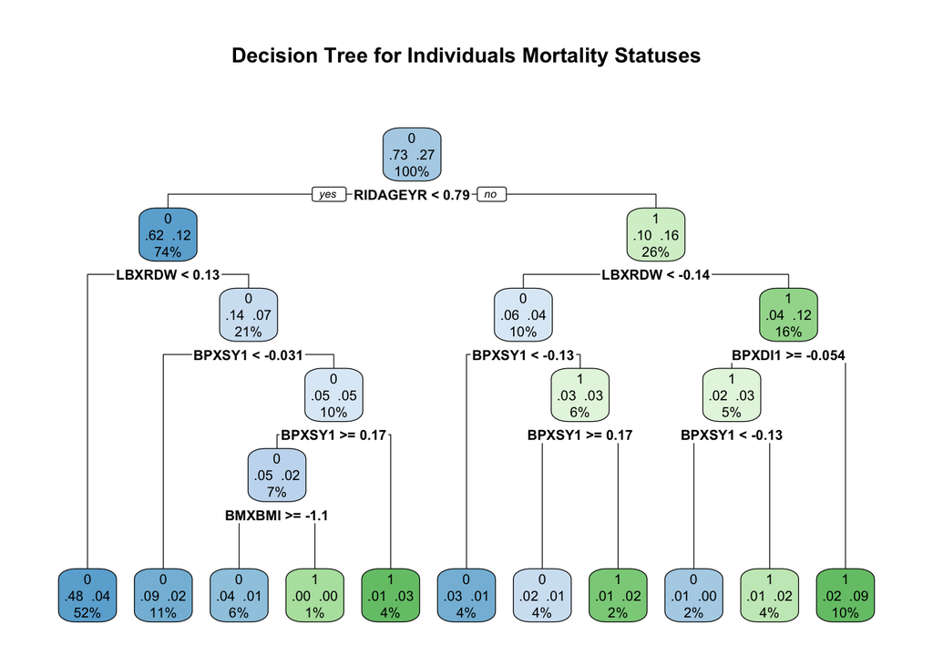

```r
# Load required packages
library(rpart)
library(rpart.plot) # Visualization of the tree
library(caret)
library(ggplot2) # Visualization


decision_tree_model <- rpart(mortstat ~ ., data = train_set, method = "class")

rpart.plot(decision_tree_model, type = 2, extra = 109, fallen.leaves = TRUE, main = "Decision Tree for Individuals Mortality Statuses")
```

```r
test_pred <- predict(decision_tree_model, newdata = test_set, type = "class")
#test_pred

confusion_matrix_dt <- confusionMatrix(test_pred, factor(test_set$mortstat), positive = "1")

print("Confusion Matrix for Decision Tree:")
```

```
## [1] "Confusion Matrix for Decision Tree:"
```

```r
print(confusion_matrix_dt)
```

```
## Confusion Matrix and Statistics
##
##           Reference
## Prediction   0   1
##          0 339  53
##          1  26  83
##
##                Accuracy : 0.8423
##                  95% CI : (0.8074, 0.8731)
##     No Information Rate : 0.7285
##     P-Value [Acc > NIR] : 1.066e-09
##
##                   Kappa : 0.5749
##
##  Mcnemar's Test P-Value : 0.003442
##
##             Sensitivity : 0.6103
##             Specificity : 0.9288
##          Pos Pred Value : 0.7615
##          Neg Pred Value : 0.8648
##              Prevalence : 0.2715
##          Detection Rate : 0.1657
##    Detection Prevalence : 0.2176
##       Balanced Accuracy : 0.7695
##
##        'Positive' Class : 1
##
```

```r
rmse_tree <- sqrt(mean((as.numeric(test_pred) - as.numeric(test_set$mortstat))^2))
cat("Root Mean Squared Error (RMSE) of Decision Tree:", rmse_tree, "\n")
```

```
## Root Mean Squared Error (RMSE) of Decision Tree: 1.024646
```

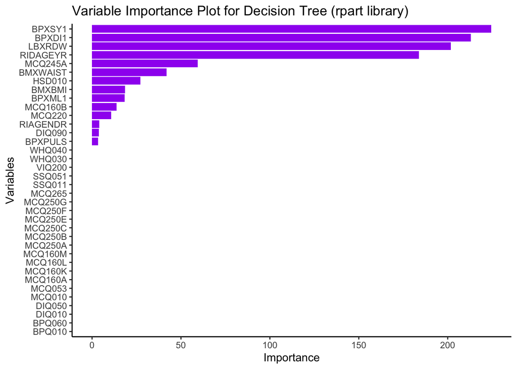

```r
var_importance <- varImp(decision_tree_model)

importance_df <- data.frame(Variable = rownames(var_importance), Importance = var_importance$Overall)

ggplot(importance_df, aes(x = reorder(Variable, Importance), y = Importance)) +
  geom_bar(stat = "identity", fill = "purple") +
  coord_flip() +  # Flip the axes for better readability
  labs(title = "Variable Importance Plot for Decision Tree (rpart library)", x = "Variables", y = "Importance") +
  theme_classic()
```

Since we are still using the full model for decision tree, based on the previous expectations, I would expect that after selecting the top variables, the model performance will improve. Therefore, I re-trained the model using the top 7 variables based on the variable importance plot: `RIDAGEYR` (Age in years), `BPXSY1` (Systolic blood pressure measured in $mm \ Hg$), `BPXDI1` (Diastolic blood pressure measured in $mm \ Hg$), `LBXRDW` (Red cell distribution width (%)), `BMXWAIST` (Waist Circumference measured in $cm$), `HSD010` (General health condition), and `MCQ245A` (Work days missed for illness/maternity).

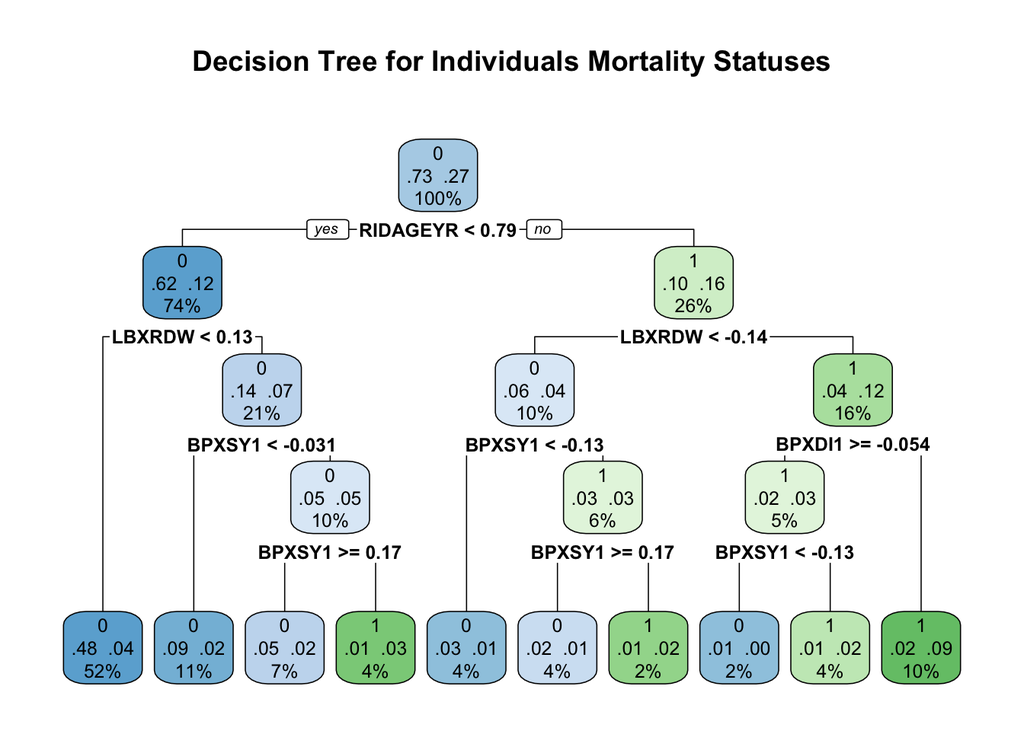

```r
decision_tree_model <- rpart(mortstat ~ BPXSY1 + BPXDI1 + LBXRDW + RIDAGEYR + MCQ245A + BMXWAIST + HSD010, data = train_set, method = "class")

rpart.plot(decision_tree_model, type = 2, extra = 109, fallen.leaves = TRUE, main = "Decision Tree for Individuals Mortality Statuses")
```

```r
test_pred <- predict(decision_tree_model, newdata = test_set, type = "class")
#test_pred

confusion_matrix_dt_best <- confusionMatrix(test_pred, factor(test_set$mortstat), positive = "1")

print("Confusion Matrix for Decision Tree:")
```

```
## [1] "Confusion Matrix for Decision Tree:"
```

```r
print(confusion_matrix_dt_best)
```

```
## Confusion Matrix and Statistics
##
##           Reference
## Prediction   0   1
##          0 339  55
##          1  26  81
##
##                Accuracy : 0.8383
##                  95% CI : (0.8031, 0.8695)
##     No Information Rate : 0.7285
##     P-Value [Acc > NIR] : 4.177e-09
##
##                   Kappa : 0.5619
##
##  Mcnemar's Test P-Value : 0.001864
##
##             Sensitivity : 0.5956
##             Specificity : 0.9288
##          Pos Pred Value : 0.7570
##          Neg Pred Value : 0.8604
##              Prevalence : 0.2715
##          Detection Rate : 0.1617
##    Detection Prevalence : 0.2136
##       Balanced Accuracy : 0.7622
##
##        'Positive' Class : 1
##
```

```r
rmse_tree_best <- sqrt(mean((as.numeric(test_pred) - as.numeric(test_set$mortstat))^2))
cat("Root Mean Squared Error (RMSE) of Decision Tree (optimized):", rmse_tree_best, "\n")
```

```
## Root Mean Squared Error (RMSE) of Decision Tree (optimized): 1.022697
```

The result, however, suggested that the model is under-fitting the data compared with training the model using the full set of variables. Both accuracy & sensitivity decreased compared to the previous decision tree model.

#### Random Forest (with and w/o Bagging)

For random forest model, we proceeded with similar procedures as the previous decision tree model. First, we run the random forest model using the full set of variables (continuous scaled). Then, based on importance plot, we **selected top few variables (most important ones) and re-train the model using random forest with bagging**.

```r
# Load required packages
library(randomForest)
library(caret)

set.seed(123)
train_set$mortstat <- as.factor(train_set$mortstat)
test_set$mortstat <- as.factor(test_set$mortstat)

rf_model <- randomForest(mortstat ~ ., data = train_set, importance = TRUE, ntree = 500)

print(rf_model)
```

```
##
## Call:
##  randomForest(formula = mortstat ~ ., data = train_set, importance = TRUE,      ntree = 500)
##                Type of random forest: classification
##                      Number of trees: 500
## No. of variables tried at each split: 6
##
##         OOB estimate of  error rate: 15.23%
## Confusion matrix:
##      0   1 class.error
## 0 1380  79  0.05414668
## 1  226 318  0.41544118
```

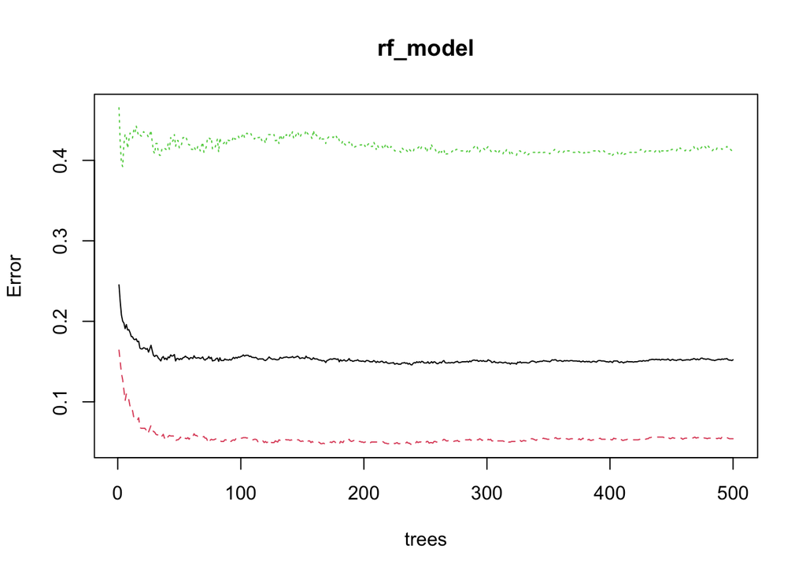

```r
plot(rf_model)
```

```r
test_pred <- predict(rf_model, test_set, type = "Class")
#test_pred_binary <- ifelse(test_pred >= 0.5, 1, 0)

actual_values <- factor(test_set$mortstat, levels = c(0, 1))
test_pred_binary <- factor(test_pred, levels = c(0, 1))

confusion_matrix_rf <- confusionMatrix(test_pred_binary, actual_values, positive = "1")

print("Confusion Matrix for Random Forest:")
```

```
## [1] "Confusion Matrix for Random Forest:"
```

```r
print(confusion_matrix_rf)
```

```
## Confusion Matrix and Statistics
##
##           Reference
## Prediction   0   1
##          0 348  43
##          1  17  93
##
##                Accuracy : 0.8802
##                  95% CI : (0.8485, 0.9074)
##     No Information Rate : 0.7285
##     P-Value [Acc > NIR] : < 2.2e-16
##
##                   Kappa : 0.6779
##
##  Mcnemar's Test P-Value : 0.001249
##
##             Sensitivity : 0.6838
##             Specificity : 0.9534
##          Pos Pred Value : 0.8455
##          Neg Pred Value : 0.8900
##              Prevalence : 0.2715
##          Detection Rate : 0.1856
##    Detection Prevalence : 0.2196
##       Balanced Accuracy : 0.8186
##
##        'Positive' Class : 1
##
```

```r
rmse_rf <- sqrt(mean((as.numeric(test_pred) - as.numeric(test_set$mortstat))^2))
cat("Root Mean Squared Error (RMSE) of Random Forest:", rmse_rf, "\n\n")
```

```
## Root Mean Squared Error (RMSE) of Random Forest: 0.3460643
```

```r
importance_df <- as.data.frame(importance(rf_model))
importance_sorted <- importance_df[order(importance_df$MeanDecreaseAccuracy, decreasing = TRUE), ]

# Show the top 6 rows
print(head(importance_sorted, 6))
```

```
##                 0        1 MeanDecreaseAccuracy MeanDecreaseGini
## RIDAGEYR 34.49459 38.74726             47.63314        118.43725
## BPXSY1   23.88527 26.95524             32.86047         97.23819
## BPXDI1   20.75821 27.30482             30.23344         89.14844
## LBXRDW   14.56960 28.34272             27.31672         85.93861
## BMXWAIST 14.65327 13.37685             18.30816         59.39071
## BPXML1   11.18228 11.07855             16.63469         39.35740
```

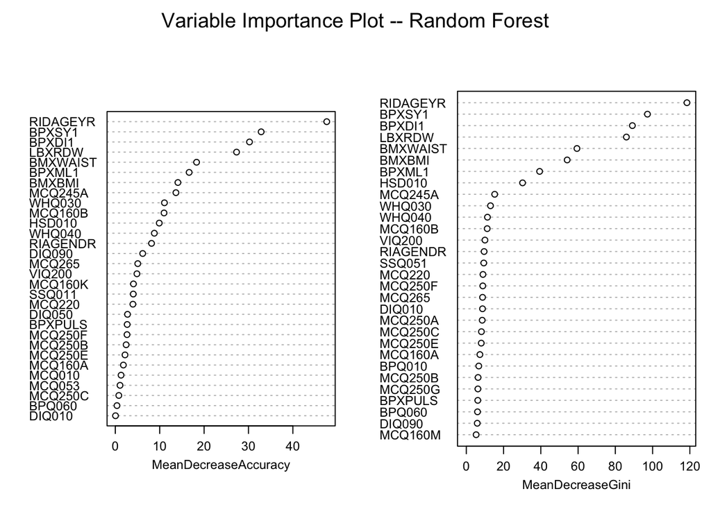

```r
varImpPlot(rf_model, main = "Variable Importance Plot -- Random Forest", cex = 0.75)
```

We can observe yet another improvement in overall model performance, with a high model accuracy over 88% and a best model sensitivity (up till now) of 68.38%; it is also worth noting that the specificity achieved over 95%, which suggest that this model is nearly perfect identifying alive individual features and picking them out. Overall speaking, we observed a huge improvement in model sensitivities for tree-based models compared to previous models tested.

```r
set.seed(123)

rf_bagging <- randomForest(mortstat ~ RIDAGEYR + BPXSY1 + BPXDI1 + LBXRDW + BMXBMI + BMXWAIST, data = train_set, mtry = 6 - 1, ntree = 500, importance = TRUE) # Perform bagging, all features were considered when trying to split the node (using `mtry`)

print(rf_bagging)
```

```
##
## Call:
##  randomForest(formula = mortstat ~ RIDAGEYR + BPXSY1 + BPXDI1 +      LBXRDW + BMXBMI + BMXWAIST, data = train_set, mtry = 6 -      1, ntree = 500, importance = TRUE)
##                Type of random forest: classification
##                      Number of trees: 500
## No. of variables tried at each split: 5
##
##         OOB estimate of  error rate: 15.08%
## Confusion matrix:
##      0   1 class.error
## 0 1359 100   0.0685401
## 1  202 342   0.3713235
```

```r
test_pred <- predict(rf_bagging, newdata = test_set, type = "class")

actual_values <- factor(test_set$mortstat, levels = c(0, 1))
test_pred_binary <- factor(test_pred, levels = c(0, 1))

cat("Confusion Matrix for Random Forest with Bagging:\n\n")
```

```
## Confusion Matrix for Random Forest with Bagging:
```

```r
confusion_matrix_rf_bagging <- confusionMatrix(test_pred_binary, actual_values, positive = "1")
confusion_matrix_rf_bagging
```

```
## Confusion Matrix and Statistics
##
##           Reference
## Prediction   0   1
##          0 343  32
##          1  22 104
##
##                Accuracy : 0.8922
##                  95% CI : (0.8617, 0.918)
##     No Information Rate : 0.7285
##     P-Value [Acc > NIR] : <2e-16
##
##                   Kappa : 0.7211
##
##  Mcnemar's Test P-Value : 0.2207
##
##             Sensitivity : 0.7647
##             Specificity : 0.9397
##          Pos Pred Value : 0.8254
##          Neg Pred Value : 0.9147
##              Prevalence : 0.2715
##          Detection Rate : 0.2076
##    Detection Prevalence : 0.2515
##       Balanced Accuracy : 0.8522
##
##        'Positive' Class : 1
##
```

After selecting for variables and added bagging to the random forest model, we can see that the model further improved its accuracy to over 89%, which is (of course) significantly better than the NIR. The model also obtained an all-time-high sensitivity of 76.47%. Considering that our data set have only ~27% of deceased individuals (both training and test set), being able to successfully predict over three quarters of them suggest that random forest (or random forest with bagging) may be the best strategy to carry out the prediction.

#### Boosting

For the last tree-based model, we carried out boosting, with tuning from a list of shrinkage values and find out the best one with smallest cross validation error.

```r
# Load required packages
library(gbm)
```

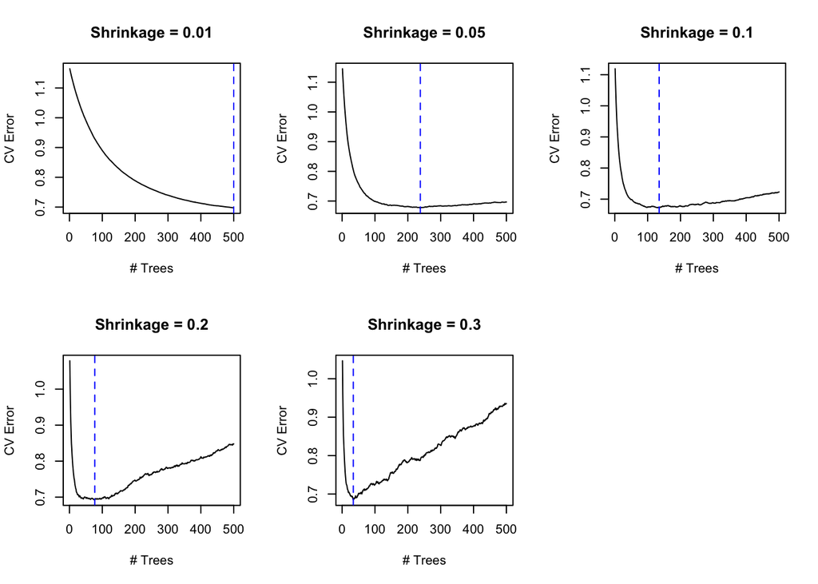

```r
train_set$mortstat <- as.numeric(train_set$mortstat) - 1
test_set$mortstat <- as.numeric(test_set$mortstat) - 1


shrinkage_values <- c(0.01, 0.05, 0.1, 0.2, 0.3)
results <- list()
plot_list <- list()


min_cv_error <- Inf
best_shrinkage <- NA

for (values in shrinkage_values) {
  gbm_model <- gbm(
    mortstat ~ .,
    data = train_set,
    distribution = "bernoulli",
    n.trees = 500,
    interaction.depth = 3,
    shrinkage = values,
    n.minobsinnode = 10,
    cv.folds = 10,
    verbose = FALSE
  )

  best_trees <- gbm.perf(gbm_model, method = "cv", plot.it = FALSE)

  # Save all training error (early stopping) plot in the list
  plot_list[[as.character(values)]] <- function(gbm_model_local, i_local) {
    plot(gbm_model_local$cv.error, type = "l", main = paste("Shrinkage =", i_local),
         ylab = "CV Error", xlab = "# Trees")
    abline(v = gbm.perf(gbm_model_local, method = "cv", plot.it = FALSE), col = "blue", lty = 2)
  }

  results[[as.character(values)]] <- list(
    model = gbm_model,
    best_trees = best_trees,
    cv_error = gbm_model$cv.error[best_trees]
  )
}

par(mfrow = c(2, 3))

for (i in names(plot_list)) {
  plot_list[[i]](results[[i]]$model, i)  # Pass the correct model and shrinkage value to each function
}

par(mfrow = c(1, 1))
```

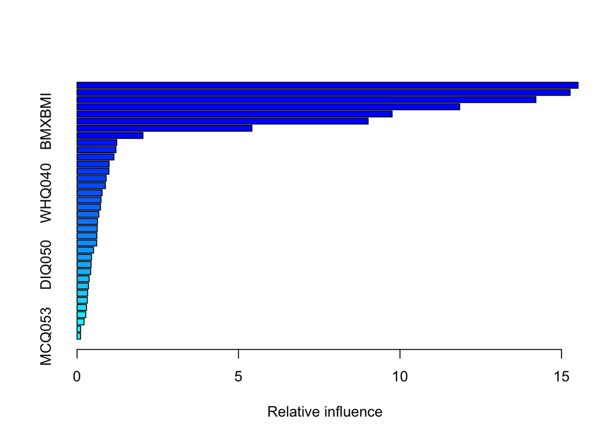

```
##               var   rel.inf
## RIDAGEYR RIDAGEYR 15.514838
## BPXSY1     BPXSY1 15.268629
## BPXDI1     BPXDI1 14.208057
## LBXRDW     LBXRDW 11.848549
## BMXWAIST BMXWAIST  9.755292
## BMXBMI     BMXBMI  9.013372
```

```r
head(summary(gbm_model), 6)
```

```r
for (i in seq_along(results)) {
  current_cv_error <- results[[i]]$cv_error

  if (current_cv_error < min_cv_error) {
    min_cv_error <- current_cv_error
    best_shrinkage <- shrinkage_values[i]  # Update best shrinkage value
  }
}

cat("Best shrinkage value:", best_shrinkage, "\n\n")
```

```
## Best shrinkage value: 0.1
```

```r
# Get the best model
best_model <- results[[as.character(best_shrinkage)]]$model
best_trees <- results[[as.character(best_shrinkage)]]$best_trees

# Make predictions on the test set using the best model
test_preds <- predict(best_model, newdata = test_set, n.trees = best_trees, type = "response")

test_preds_binary <- ifelse(test_preds >= 0.5, 1, 0)

# Confusion matrix
confusion_matrix_gbm <- confusionMatrix(as.factor(test_preds_binary), as.factor(test_set$mortstat), positive = "1")

print(confusion_matrix_gbm)
```

```
## Confusion Matrix and Statistics
##
##           Reference
## Prediction   0   1
##          0 341  41
##          1  24  95
##
##                Accuracy : 0.8703
##                  95% CI : (0.8376, 0.8984)
##     No Information Rate : 0.7285
##     P-Value [Acc > NIR] : 1.338e-14
##
##                   Kappa : 0.6586
##
##  Mcnemar's Test P-Value : 0.04719
##
##             Sensitivity : 0.6985
##             Specificity : 0.9342
##          Pos Pred Value : 0.7983
##          Neg Pred Value : 0.8927
##              Prevalence : 0.2715
##          Detection Rate : 0.1896
##    Detection Prevalence : 0.2375
##       Balanced Accuracy : 0.8164
##
##        'Positive' Class : 1
##
```

```r
# Calculate RMSE
rmse_gbm <- sqrt(mean((as.numeric(test_preds_binary) - as.numeric(test_set$mortstat))^2))
cat("Best GBM Root Mean Squared Error (RMSE) with tuned shrinkage value:", rmse_gbm, "\n")
```

```
## Best GBM Root Mean Squared Error (RMSE) with tuned shrinkage value: 0.3601951
```

1. GBM is prone to over-fitting, since trees are build sequentially to correct for errors of the previous tree;
2. Random forest, compared to GBM, is less sensitive to imbalanced data. Especially for the case of bagging, since it builds independent trees on bootstrapped samples.
3. Random Forest is a collection of decision trees built in parallel. This could suggest better generalization on the minority class. In our cases, the minority class is the deceased individuals (group 1).

### Support Vector Machines (SVMs)

As the last part of the model construction and testing, we perform Support Vector Machines (SVMs) model construction, tuning, and testing. All three major kernels, including linear, radial, and polynomial kernels were tested. Cost, $\gamma$, and degrees of polynomials were looped through a ranges of values.

As for the variable selection, considering that the Support Vector Machines are designed to separate two classes by a hyper-plane that maximize the distances (linear kernel for linear SVMs, radial / polynomial kernel SVMs for higher degrees), the models need to calculate distances between data points, so they expect all the variables fitted to be numerical. This suggests that encoded categorical variables are necessary before feeding into the SVM model. However, the performance of SVMs can be subject to highly correlated values after encoding (or multi-olinearity), and it performed poorly when we include the encoded variables in the model. Therefore, we finally decided to only use continuous variables to train & build SVM models.

```r
library(e1071)

train_set$mortstat <- as.factor(train_set$mortstat)
test_set$mortstat <- as.factor(test_set$mortstat)

cost <- c(0.001, 0.01, 0.1, 1, 10)
gamma <- c(0.0001, 0.001, 0.01, 0.1, 1)
degrees <- c(2, 3, 4)

# Linear kernel

svm_linear_tune <- tune(svm,
                        mortstat ~ .,
                        data = train_set %>% dplyr::select(all_of(continuous_vars), mortstat), # Include only continuous variables
                        kernel = "linear",
                        ranges = list(cost = cost))

summary(svm_linear_tune)
```

```
##
## Parameter tuning of 'svm':
##
## - sampling method: 10-fold cross validation
##
## - best parameters:
##  cost
##   0.1
##
## - best performance: 0.2086841
##
## - Detailed performance results:
##    cost     error dispersion
## 1 1e-03 0.2715697 0.03931731
## 2 1e-02 0.2346169 0.03410021
## 3 1e-01 0.2086841 0.02768178
## 4 1e+00 0.2096841 0.02858692
## 5 1e+01 0.2101841 0.02814756
```

```r
best_svm_model <- svm_linear_tune$best.model
test_pred_linear <- predict(best_svm_model, newdata = test_set)
confusion_matrix_linear <- confusionMatrix(as.factor(test_pred_linear), as.factor(test_set$mortstat), positive = "1")
confusion_matrix_linear
```

```
## Confusion Matrix and Statistics
##
##           Reference
## Prediction   0   1
##          0 340  72
##          1  25  64
##
##                Accuracy : 0.8064
##                  95% CI : (0.769, 0.8401)
##     No Information Rate : 0.7285
##     P-Value [Acc > NIR] : 3.235e-05
##
##                   Kappa : 0.451
##
##  Mcnemar's Test P-Value : 3.003e-06
##
##             Sensitivity : 0.4706
##             Specificity : 0.9315
##          Pos Pred Value : 0.7191
##          Neg Pred Value : 0.8252
##              Prevalence : 0.2715
##          Detection Rate : 0.1277
##    Detection Prevalence : 0.1776
##       Balanced Accuracy : 0.7010
##
##        'Positive' Class : 1
##
```

```r
rmse_linear_svm <- sqrt(mean((as.numeric(test_pred_linear) - as.numeric(test_set$mortstat))^2))
cat("Best Root Mean Squared Error (RMSE) of SVM with linear kernel:", rmse_linear_svm, "\n\n")
```

```
## Best Root Mean Squared Error (RMSE) of SVM with linear kernel: 0.4400145
```

```r
# Radial kernel

svm_tune_rad <- tune(svm,
                     mortstat ~ .,
                     data = train_set %>% dplyr::select(all_of(continuous_vars), mortstat),
                     kernel = "radial",
                     ranges = list(cost = cost, gamma = gamma))

summary(svm_tune_rad)
```

```
##
## Parameter tuning of 'svm':
##
## - sampling method: 10-fold cross validation
##
## - best parameters:
##  cost gamma
##     1     1
##
## - best performance: 0.204194
##
## - Detailed performance results:
##     cost gamma     error dispersion
## 1  1e-03 1e-04 0.2715871 0.02344376
## 2  1e-02 1e-04 0.2715871 0.02344376
## 3  1e-01 1e-04 0.2715871 0.02344376
## 4  1e+00 1e-04 0.2715871 0.02344376
## 5  1e+01 1e-04 0.2720896 0.02507695
## 6  1e-03 1e-03 0.2715871 0.02344376
## 7  1e-02 1e-03 0.2715871 0.02344376
## 8  1e-01 1e-03 0.2715871 0.02344376
## 9  1e+00 1e-03 0.2720896 0.02507695
## 10 1e+01 1e-03 0.2072040 0.01872829
## 11 1e-03 1e-02 0.2715871 0.02344376
## 12 1e-02 1e-02 0.2715871 0.02344376
## 13 1e-01 1e-02 0.2715871 0.02344376
## 14 1e+00 1e-02 0.2077139 0.01984461
## 15 1e+01 1e-02 0.2057239 0.02261583
## 16 1e-03 1e-01 0.2715871 0.02344376
## 17 1e-02 1e-01 0.2715871 0.02344376
## 18 1e-01 1e-01 0.2112114 0.02656372
## 19 1e+00 1e-01 0.2052164 0.02287360
## 20 1e+01 1e-01 0.2072114 0.02705569
## 21 1e-03 1e+00 0.2715871 0.02344376
## 22 1e-02 1e+00 0.2715871 0.02344376
## 23 1e-01 1e+00 0.2366542 0.02144010
## 24 1e+00 1e+00 0.2041940 0.02164145
## 25 1e+01 1e+00 0.2216592 0.02430682
```

```r
best_svm_model <- svm_tune_rad$best.model
test_pred_radial <- predict(best_svm_model, newdata = test_set)
confusion_matrix_radial <- confusionMatrix(as.factor(test_pred_radial), as.factor(test_set$mortstat), positive = "1")
confusion_matrix_radial
```

```
## Confusion Matrix and Statistics
##
##           Reference
## Prediction   0   1
##          0 336  65
##          1  29  71
##
##                Accuracy : 0.8124
##                  95% CI : (0.7754, 0.8456)
##     No Information Rate : 0.7285
##     P-Value [Acc > NIR] : 7.781e-06
##
##                   Kappa : 0.4827
##
##  Mcnemar's Test P-Value : 0.0003062
##
##             Sensitivity : 0.5221
##             Specificity : 0.9205
##          Pos Pred Value : 0.7100
##          Neg Pred Value : 0.8379
##              Prevalence : 0.2715
##          Detection Rate : 0.1417
##    Detection Prevalence : 0.1996
##       Balanced Accuracy : 0.7213
##
##        'Positive' Class : 1
##
```

```r
rmse_radial_svm <- sqrt(mean((as.numeric(test_pred_radial) - as.numeric(test_set$mortstat))^2))
cat("Best Root Mean Squared Error (RMSE) of SVM with radial kernel:", rmse_radial_svm, "\n\n")
```

```
## Best Root Mean Squared Error (RMSE) of SVM with radial kernel: 0.4331567
```

```r
# Polynomial kernel

svm_tune_poly <- tune(svm,
                      mortstat ~ .,
                      data = train_set %>% dplyr::select(all_of(continuous_vars), mortstat),
                      kernel = "polynomial",
                      ranges = list(cost = cost, degree = degrees))

summary(svm_tune_poly)
```

```
##
## Parameter tuning of 'svm':
##
## - sampling method: 10-fold cross validation
##
## - best parameters:
##  cost degree
##     1      3
##
## - best performance: 0.2086667
##
## - Detailed performance results:
##     cost degree     error dispersion
## 1  1e-03      2 0.2715622 0.04692189
## 2  1e-02      2 0.2720622 0.04639427
## 3  1e-01      2 0.2725622 0.04820364
## 4  1e+00      2 0.2730622 0.04773677
## 5  1e+01      2 0.2730622 0.04773677
## 6  1e-03      3 0.2725597 0.04737769
## 7  1e-02      3 0.2700622 0.04802361
## 8  1e-01      3 0.2505995 0.03539142
## 9  1e+00      3 0.2086667 0.02821370
## 10 1e+01      3 0.2106642 0.02566290
## 11 1e-03      4 0.2715597 0.04806593
## 12 1e-02      4 0.2720597 0.04869573
## 13 1e-01      4 0.2705622 0.04451744
## 14 1e+00      4 0.2585746 0.03316159
## 15 1e+01      4 0.2635721 0.02723828
```

```r
best_svm_model <- svm_tune_poly$best.model
test_pred_poly <- predict(best_svm_model, newdata = test_set)
confusion_matrix_poly <- confusionMatrix(as.factor(test_pred_poly), as.factor(test_set$mortstat), positive = "1")
confusion_matrix_poly
```

```
## Confusion Matrix and Statistics
##
##           Reference
## Prediction   0   1
##          0 341  83
##          1  24  53
##
##                Accuracy : 0.7864
##                  95% CI : (0.7479, 0.8215)
##     No Information Rate : 0.7285
##     P-Value [Acc > NIR] : 0.001718
##
##                   Kappa : 0.375
##
##  Mcnemar's Test P-Value : 2.058e-08
##
##             Sensitivity : 0.3897
##             Specificity : 0.9342
##          Pos Pred Value : 0.6883
##          Neg Pred Value : 0.8042
##              Prevalence : 0.2715
##          Detection Rate : 0.1058
##    Detection Prevalence : 0.1537
##       Balanced Accuracy : 0.6620
##
##        'Positive' Class : 1
##
```

```r
rmse_poly_svm <- sqrt(mean((as.numeric(test_pred_poly) - as.numeric(test_set$mortstat))^2))
cat("Best Root Mean Squared Error (RMSE) of SVM with polynomial kernel:", rmse_poly_svm, "\n\n")
```

```
## Best Root Mean Squared Error (RMSE) of SVM with polynomial kernel: 0.4621394
```

## Conclusion

```r
conf_matrix_list <- c(confusion_matrix_logistic,
                      confusion_matrix_logistic_best,
                      confusion_matrix_lasso,
                      confusion_matrix_lasso_best,
                      confusion_matrix_ridge,
                      confusion_matrix_ridge_best,
                      confusion_matrix_lda,
                      confusion_matrix_qda,
                      confusion_matrix_dt,
                      confusion_matrix_dt_best,
                      confusion_matrix_rf,
                      confusion_matrix_rf_bagging,
                      confusion_matrix_gbm,
                      confusion_matrix_linear,
                      confusion_matrix_radial,
                      confusion_matrix_poly)

model_labels <- c("Logistic",
                  "Logistic Best Model",
                  "Lasso",
                  "Lasso Best Model",
                  "Ridge",
                  "Ridge Best Model",
                  "LDA",
                  "QDA",
                  "Decision Tree",
                  "Adjusted Decision Tree",
                  "Random Forest",
                  "Random Forest w/ Bagging",
                  "GBM",
                  "SVM Linear",
                  "SVM Radial",
                  "SVM Poly")

metrics_df <- data.frame(
  Accuracy = numeric(),
  Sensitivity = numeric(),
  Specificity = numeric(),
  Model = character(),
  stringsAsFactors = FALSE
)

label_n <- 1


for (i in seq(1, length(conf_matrix_list), by = 6)) {
  # Extract metrics
  #conf_matrix <- conf_matrix_list[[i]]
  accuracy <- conf_matrix_list[[i+2]]['Accuracy'][[1]]
  #print(accuracy)
  sensitivity <- conf_matrix_list[[i+3]]['Sensitivity'][[1]]
  specificity <- conf_matrix_list[[i+3]]['Specificity'][[1]]

  metrics_df <- rbind(metrics_df, data.frame(
    Accuracy = as.numeric(accuracy),
    Sensitivity = as.numeric(sensitivity),
    Specificity = as.numeric(specificity),
    Model = model_labels[label_n]
  ))
  label_n <- label_n + 1
}

metrics_df <- metrics_df[order(-metrics_df$Accuracy, -metrics_df$Sensitivity), ]

metrics_df$Model_Group <- ifelse(grepl("SVM", metrics_df$Model), "SVM",
                          ifelse(grepl("Tree|Random|GBM", metrics_df$Model), "Tree-based Model",
                          ifelse(grepl("Logistic|Lasso|Ridge", metrics_df$Model), "Logistic/Lasso/Ridge",
                          ifelse(grepl("QDA|LDA", metrics_df$Model), "QDA/LDA", "Other"))))

print(metrics_df)
```

```
##     Accuracy Sensitivity Specificity                    Model
## 12 0.8922156   0.7647059   0.9397260 Random Forest w/ Bagging
## 11 0.8802395   0.6838235   0.9534247            Random Forest
## 13 0.8702595   0.6985294   0.9342466                      GBM
## 9  0.8423154   0.6102941   0.9287671            Decision Tree
## 10 0.8383234   0.5955882   0.9287671   Adjusted Decision Tree
## 15 0.8123752   0.5220588   0.9205479               SVM Radial
## 14 0.8063872   0.4705882   0.9315068               SVM Linear
## 8  0.8023952   0.5735294   0.8876712                      QDA
## 7  0.8003992   0.5661765   0.8876712                      LDA
## 2  0.8003992   0.4779412   0.9205479      Logistic Best Model
## 4  0.7944112   0.4926471   0.9068493         Lasso Best Model
## 3  0.7944112   0.4705882   0.9150685                    Lasso
## 6  0.7944112   0.4705882   0.9150685         Ridge Best Model
## 1  0.7864271   0.4926471   0.8958904                 Logistic
```

[output cut: 19 more lines]

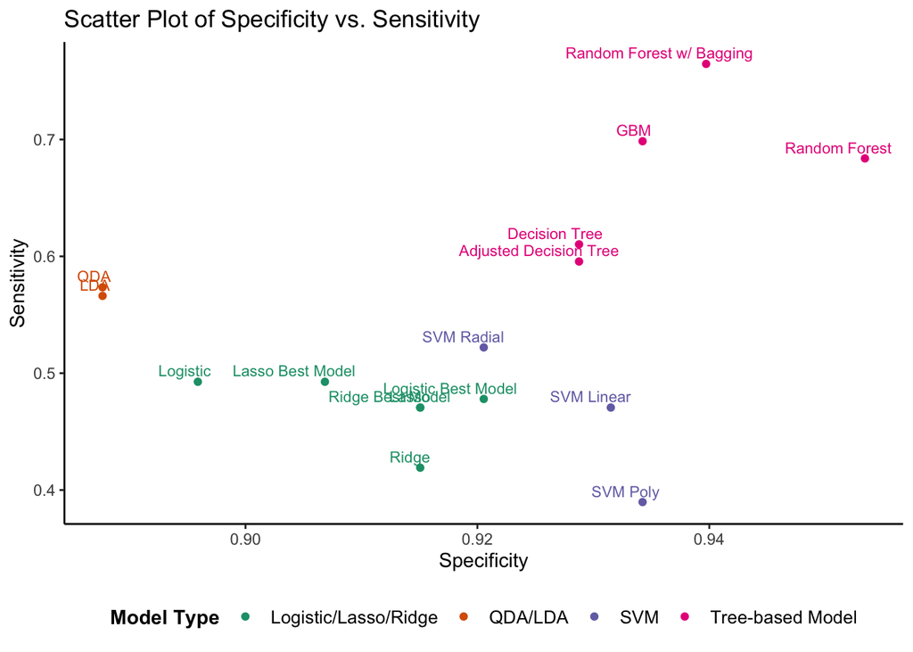

```r
ggplot(metrics_df, aes(x = Specificity, y = Sensitivity, color = Model_Group, label = Model)) +
  scale_color_brewer(palette="Dark2") +
  geom_point() +
  geom_text(vjust = -0.5, hjust = 0.75, size = 3, show.legend = FALSE) +
  labs(
    title = "Scatter Plot of Specificity vs. Sensitivity",
    x = "Specificity",
    y = "Sensitivity",
    color = "Model Type"
  ) +
  theme_classic() +
  theme(
    legend.position = "bottom",
    legend.title = element_text(size = 11, face = "bold"),
    legend.text = element_text(size = 10)
  )
```

Based on the model metrics data frame and the scatter plot, we can see that tree-based models performed the best with **the highest accuracy & model sensitivity**, with **Random Forest with Bagging being the model with the overall best performance**. This suggests that Random Forest with Bagging correctly predicted the mortality statuses of around 90% of the individuals in the test set, and correctly identified over 76% of the deceased individuals (with a training data of only 27% of deceased individuals available). This makes it the best model for the given `NHANES 2003-2004` data set.